# PCA EFA: GRAVIER

Jose Tamez

2023-05-23

# 1 GRAVIER Univariate

### 1.0.1 Loading the libraries

```r
library("FRESA.CAD")
library(psych)
library(whitening)
library("vioplot")

library(readxl)
op <- par(no.readonly = TRUE)
pander::panderOptions('digits', 3)
pander::panderOptions('table.split.table', 400)
pander::panderOptions('keep.trailing.zeros',TRUE)
```

## 1.1 The Data

```r
data('gravier', package = 'datamicroarray')
table(gravier$y)
```

```
#>
#> good poor
#>  111   57
```

```r
gravierset <- as.data.frame(cbind(class=1*(gravier$y=="poor"),gravier$x))

gravier <- NULL
```

#### 1.1.0.1 Training and testing sets

```r
dataframe <- gravierset
outcome <- "class"

trainFraction <- 0.5
rhoThreshold <- 0.6
TopVariables <- 5
aucTHR <- 0.55

set.seed(5)
trainSample <- sample(nrow(dataframe),nrow(dataframe)*trainFraction)

trainDataFrame <- dataframe[trainSample,]
testDataFrame <- dataframe[-trainSample,]
```

### 1.1.1 Data specs

```r
pander::pander(c(rows=nrow(dataframe),col=ncol(dataframe)-1))
```

| rows | col |
| --- | --- |
| 168 | 2905 |

```r
pander::pander(table(dataframe[,outcome]))
```

| 0 | 1 |
| --- | --- |
| 111 | 57 |

```r
pander::pander(table(trainDataFrame[,outcome]))
```

| 0 | 1 |
| --- | --- |
| 50 | 34 |

```r
pander::pander(table(testDataFrame[,outcome]))
```

| 0 | 1 |
| --- | --- |
| 61 | 23 |

```r
varlist <- colnames(dataframe)
varlist <- varlist[varlist != outcome]
```

## 1.2 Univariate

```r
univariate_columns <- c("caseMean","caseStd","controlMean","controlStd","controlKSP","IDI","ROCAUC","cStatCorr")
univar <- uniRankVar(varlist,
               paste(outcome,"~1"),
               outcome,
               trainDataFrame,
              rankingTest = "CStat")
```

100 : g1A07 200 : g3H03 300 : g1E07 400 : g4F03 500 : g4C05  
600 : g1int292 700 : g1int356 800 : g7A03 900 : g4D11 1000 : g1int577  
1100 : g1CNS420 1200 : g7G07 1300 : g1int785 1400 : g1CNS59 1500 : g1CNS178  
1600 : g1int949 1700 : g1int1028 1800 : g1int1089 1900 : g11D05 2000 : g1int1222  
2100 : g1int1298 2200 : g1int1376 2300 : g1int1449 2400 : g10E08 2500 : g1CNS90  
2600 : g7F11 2700 : g1int1693 2800 : g1CNS93 2900 : g1int1800

```r
#univar$orderframe[1:5,univariate_columns]
univarTest <- uniRankVar(varlist,
               paste(outcome,"~1"),
               outcome,
               trainDataFrame,
               testData=testDataFrame,
              rankingTest = "CStat")
```

100 : g1A07 200 : g3H03 300 : g1E07 400 : g4F03 500 : g4C05  
600 : g1int292 700 : g1int356 800 : g7A03 900 : g4D11 1000 : g1int577  
1100 : g1CNS420 1200 : g7G07 1300 : g1int785 1400 : g1CNS59 1500 : g1CNS178  
1600 : g1int949 1700 : g1int1028 1800 : g1int1089 1900 : g11D05 2000 : g1int1222  
2100 : g1int1298 2200 : g1int1376 2300 : g1int1449 2400 : g10E08 2500 : g1CNS90  
2600 : g7F11 2700 : g1int1693 2800 : g1CNS93 2900 : g1int1800

```r
univar$orderframe$BACC <- (univar$orderframe$Sensitivity + univar$orderframe$Specificity)/2.0
univarTest$orderframe$BACC <- (univarTest$orderframe$Sensitivity + univarTest$orderframe$Specificity)/2.0

#pROC::roc(trainDataFrame$class,trainDataFrame[,univar$orderframe$Name[1]],direction=">",plot=TRUE,auc=TRUE,quiet = TRUE)
```

## 1.3 Decorrelation with UPSTM Blind

```r
DEdataframe <- IDeA(trainDataFrame,thr=rhoThreshold)
predTestDe <- predictDecorrelate(DEdataframe,testDataFrame)

ltvar <- getLatentCoefficients(DEdataframe);
pander::pander(head(ltvar))
```

- **La_g2E09**:

  | g2E09 | g2F10 |
  | --- | --- |
  | 1 | -0.834 |

- **La_g7F07**:

  | g7F07 | g2F10 |
  | --- | --- |
  | 1 | -1.12 |

- **La_g1A01**:

  | g1A01 | g1int2 |
  | --- | --- |
  | 1 | -0.896 |

- **La_g1A08**:

  | g1A08 | g1E11 |
  | --- | --- |
  | 1 | -0.878 |

- **La_g1B01**:

  | g1B01 | g2H08 |
  | --- | --- |
  | 1 | -0.834 |

- **La_g1int1**:

  | g1int1 | g2F10 |
  | --- | --- |
  | 1 | -0.877 |

```r
pander::pander(c(Avlen=mean(sapply(ltvar,length))))
```

| Avlen |
| --- |
| 2.07 |

```r
pander::pander(c(Latent=length(ltvar)))
```

| Latent |
| --- |
| 2303 |

```r
varlistDe <-  colnames(DEdataframe)[colnames(DEdataframe) != outcome];
univarDe <- uniRankVar(varlistDe,
              paste(outcome,"~1"),
                outcome,
              DEdataframe,
              rankingTest = "CStat")
```

100 : La_g1A07 200 : La_g3H03 300 : La_g1E07 400 : La_g4F03 500 : g4C05  
600 : g1int292 700 : La_g1int356 800 : La_g7A03 900 : La_g4D11 1000 : La_g1int577  
1100 : La_g1CNS420 1200 : La_g7G07 1300 : La_g1int785 1400 : La_g1CNS59 1500 : La_g1CNS178  
1600 : La_g1int949 1700 : La_g1int1028 1800 : La_g1int1089 1900 : La_g11D05 2000 : La_g1int1222  
2100 : La_g1int1298 2200 : g1int1376 2300 : La_g1int1449 2400 : La_g10E08 2500 : g1CNS90  
2600 : g7F11 2700 : g1int1693 2800 : La_g1CNS93 2900 : La_g1int1800

```r
univarDeTest <- uniRankVar(varlistDe,
              paste(outcome,"~1"),
                outcome,
              DEdataframe,
              testData=predTestDe,
              rankingTest = "CStat")
```

100 : La_g1A07 200 : La_g3H03 300 : La_g1E07 400 : La_g4F03 500 : g4C05  
600 : g1int292 700 : La_g1int356 800 : La_g7A03 900 : La_g4D11 1000 : La_g1int577  
1100 : La_g1CNS420 1200 : La_g7G07 1300 : La_g1int785 1400 : La_g1CNS59 1500 : La_g1CNS178  
1600 : La_g1int949 1700 : La_g1int1028 1800 : La_g1int1089 1900 : La_g11D05 2000 : La_g1int1222  
2100 : La_g1int1298 2200 : g1int1376 2300 : La_g1int1449 2400 : La_g10E08 2500 : g1CNS90  
2600 : g7F11 2700 : g1int1693 2800 : La_g1CNS93 2900 : La_g1int1800

```r
univarDe$orderframe$BACC <- (univarDe$orderframe$Sensitivity + univarDe$orderframe$Specificity)/2.0
univarDeTest$orderframe$BACC <- (univarDeTest$orderframe$Sensitivity + univarDeTest$orderframe$Specificity)/2.0

#univarDe$orderframe[1:5,univariate_columns]
#univarDeTest$orderframe[1:5,univariate_columns]

#pROC::roc(DEdataframe$class,DEdataframe[,univarDe$orderframe$Name[1]],direction=">",plot=TRUE,auc=TRUE,quiet = TRUE)
```

## 1.4 Decorrelation with UPSTM Blind/Spearman

```r
DEdataframeSpear <- IDeA(trainDataFrame,thr=rhoThreshold,method="spearman")
predTestDeSpear <- predictDecorrelate(DEdataframeSpear,testDataFrame)

ltvar <- getLatentCoefficients(DEdataframeSpear);
pander::pander(head(ltvar))
```

- **La_g2E09**:

  | g2E09 | g1A05 |
  | --- | --- |
  | 1 | -0.71 |

- **La_g7F07**:

  | g7F07 | g2G09 |
  | --- | --- |
  | 1 | -1.1 |

- **La_g1A01**:

  | g1A01 | g2B08 |
  | --- | --- |
  | 1 | -0.897 |

- **La_g3H08**:

  | g3C09 | g3H08 |
  | --- | --- |
  | -0.42 | 1 |

- **La_g1A08**:

  | g1A08 | g1E11 |
  | --- | --- |
  | 1 | -0.878 |

- **La_g1B01**:

  | g1B01 | g1G11 |
  | --- | --- |
  | 1 | -0.825 |

```r
pander::pander(c(Avlen=mean(sapply(ltvar,length))))
```

| Avlen |
| --- |
| 2.07 |

```r
pander::pander(c(Latent=length(ltvar)))
```

| Latent |
| --- |
| 2015 |

```r
varlistDeSpear <-  colnames(DEdataframeSpear)[colnames(DEdataframeSpear) != outcome];
univarDeSpear <- uniRankVar(varlistDeSpear,
              paste(outcome,"~1"),
                outcome,
              DEdataframeSpear,
              rankingTest = "CStat")
```

100 : La_g1A07 200 : g3H03 300 : La_g1E07 400 : La_g4F03 500 : g4C05  
600 : g1int292 700 : g1int356 800 : La_g7A03 900 : La_g4D11 1000 : La_g1int577  
1100 : g1CNS420 1200 : La_g7G07 1300 : La_g1int785 1400 : La_g1CNS59 1500 : La_g1CNS178  
1600 : g1int949 1700 : La_g1int1028 1800 : La_g1int1089 1900 : La_g11D05 2000 : La_g1int1222  
2100 : La_g1int1298 2200 : La_g1int1376 2300 : La_g1int1449 2400 : La_g10E08 2500 : g1CNS90  
2600 : g7F11 2700 : g1int1693 2800 : La_g1CNS93 2900 : La_g1int1800

```r
univarDeSpearTest <- uniRankVar(varlistDeSpear,
              paste(outcome,"~1"),
                outcome,
              DEdataframeSpear,
              testData=predTestDeSpear,
              rankingTest = "CStat")
```

100 : La_g1A07 200 : g3H03 300 : La_g1E07 400 : La_g4F03 500 : g4C05  
600 : g1int292 700 : g1int356 800 : La_g7A03 900 : La_g4D11 1000 : La_g1int577  
1100 : g1CNS420 1200 : La_g7G07 1300 : La_g1int785 1400 : La_g1CNS59 1500 : La_g1CNS178  
1600 : g1int949 1700 : La_g1int1028 1800 : La_g1int1089 1900 : La_g11D05 2000 : La_g1int1222  
2100 : La_g1int1298 2200 : La_g1int1376 2300 : La_g1int1449 2400 : La_g10E08 2500 : g1CNS90  
2600 : g7F11 2700 : g1int1693 2800 : La_g1CNS93 2900 : La_g1int1800

```r
univarDeSpear$orderframe$BACC <- (univarDeSpear$orderframe$Sensitivity + univarDeSpear$orderframe$Specificity)/2.0
univarDeSpearTest$orderframe$BACC <- (univarDeSpearTest$orderframe$Sensitivity + univarDeSpearTest$orderframe$Specificity)/2.0
```

## 1.5 Decorrelation with UPSTM Driven

```r
DriDEdataframe <- IDeA(trainDataFrame,Outcome=outcome,thr=rhoThreshold)
predTestDri <- predictDecorrelate(DriDEdataframe,testDataFrame)


ltvar <- getLatentCoefficients(DriDEdataframe);
pander::pander(head(ltvar))
```

- **La_g2E09**:

  | g2E09 | g2F10 |
  | --- | --- |
  | 1 | -0.834 |

- **La_g7F07**:

  | g7F07 | g2C01 |
  | --- | --- |
  | 1 | -0.771 |

- **La_g1A01**:

  | g1A01 | g1int2 |
  | --- | --- |
  | 1 | -0.896 |

- **La_g1A08**:

  | g1A08 | g3C05 |
  | --- | --- |
  | 1 | -0.891 |

- **La_g1B01**:

  | g1B01 | g3F07 |
  | --- | --- |
  | 1 | -0.913 |

- **La_g1int1**:

  | g1int1 | g2F10 |
  | --- | --- |
  | 1 | -0.877 |

```r
pander::pander(c(Avlen=mean(sapply(ltvar,length))))
```

| Avlen |
| --- |
| 2.07 |

```r
pander::pander(c(Latent=length(ltvar)))
```

| Latent |
| --- |
| 2315 |

```r
varlistDe <-  colnames(DriDEdataframe)[colnames(DriDEdataframe) != outcome];
univarDeDri <- uniRankVar(varlistDe,
              paste(outcome,"~1"),
                outcome,
              DriDEdataframe,
              rankingTest = "CStat")
```

100 : La_g1A07 200 : La_g3H03 300 : La_g1E07 400 : La_g4F03 500 : g4C05  
600 : g1int292 700 : La_g1int356 800 : La_g7A03 900 : La_g4D11 1000 : La_g1int577  
1100 : g1CNS420 1200 : La_g7G07 1300 : La_g1int785 1400 : La_g1CNS59 1500 : La_g1CNS178  
1600 : g1int949 1700 : La_g1int1028 1800 : La_g1int1089 1900 : La_g11D05 2000 : La_g1int1222  
2100 : La_g1int1298 2200 : La_g1int1376 2300 : La_g1int1449 2400 : La_g10E08 2500 : g1CNS90  
2600 : g7F11 2700 : g1int1693 2800 : La_g1CNS93 2900 : La_g1int1800

```r
univarDeDriTest <- uniRankVar(varlistDe,
              paste(outcome,"~1"),
                outcome,
              DriDEdataframe,
              testData=predTestDri,
              rankingTest = "CStat")
```

100 : La_g1A07 200 : La_g3H03 300 : La_g1E07 400 : La_g4F03 500 : g4C05  
600 : g1int292 700 : La_g1int356 800 : La_g7A03 900 : La_g4D11 1000 : La_g1int577  
1100 : g1CNS420 1200 : La_g7G07 1300 : La_g1int785 1400 : La_g1CNS59 1500 : La_g1CNS178  
1600 : g1int949 1700 : La_g1int1028 1800 : La_g1int1089 1900 : La_g11D05 2000 : La_g1int1222  
2100 : La_g1int1298 2200 : La_g1int1376 2300 : La_g1int1449 2400 : La_g10E08 2500 : g1CNS90  
2600 : g7F11 2700 : g1int1693 2800 : La_g1CNS93 2900 : La_g1int1800

```r
univarDeDri$orderframe$BACC <- (univarDeDri$orderframe$Sensitivity + univarDeDri$orderframe$Specificity)/2.0
univarDeDriTest$orderframe$BACC <- (univarDeDriTest$orderframe$Sensitivity + univarDeDriTest$orderframe$Specificity)/2.0
```

## 1.6 Decorrelation with UPSTM Driven and Spearman

```r
DriDEdataframeSpear <- IDeA(trainDataFrame,Outcome=outcome,thr=rhoThreshold,method="spearman")
predTestDriSpear <- predictDecorrelate(DriDEdataframeSpear,testDataFrame)


ltvar <- getLatentCoefficients(DriDEdataframeSpear);
pander::pander(head(ltvar))
```

- **La_g2E09**:

  | g2E09 | g1A05 |
  | --- | --- |
  | 1 | -0.71 |

- **La_g7F07**:

  | g7F07 | g2G09 |
  | --- | --- |
  | 1 | -1.1 |

- **La_g1A01**:

  | g1A01 | g2B08 |
  | --- | --- |
  | 1 | -0.897 |

- **La_g3H08**:

  | g3C09 | g3H08 |
  | --- | --- |
  | -0.42 | 1 |

- **La_g1A08**:

  | g1A08 | g1E11 |
  | --- | --- |
  | 1 | -0.878 |

- **La_g1B01**:

  | g1B01 | g1G11 |
  | --- | --- |
  | 1 | -0.825 |

```r
pander::pander(c(Avlen=mean(sapply(ltvar,length))))
```

| Avlen |
| --- |
| 2.05 |

```r
pander::pander(c(Latent=length(ltvar)))
```

| Latent |
| --- |
| 2015 |

```r
varlistDeSpear <-  colnames(DriDEdataframeSpear)[colnames(DriDEdataframeSpear) != outcome];
univarDeDriSpear <- uniRankVar(varlistDeSpear,
              paste(outcome,"~1"),
                outcome,
              DriDEdataframeSpear,
              rankingTest = "CStat")
```

100 : La_g1A07 200 : g3H03 300 : La_g1E07 400 : La_g4F03 500 : g4C05  
600 : g1int292 700 : g1int356 800 : La_g7A03 900 : La_g4D11 1000 : g1int577  
1100 : g1CNS420 1200 : La_g7G07 1300 : g1int785 1400 : La_g1CNS59 1500 : La_g1CNS178  
1600 : g1int949 1700 : La_g1int1028 1800 : La_g1int1089 1900 : La_g11D05 2000 : La_g1int1222  
2100 : La_g1int1298 2200 : La_g1int1376 2300 : La_g1int1449 2400 : La_g10E08 2500 : g1CNS90  
2600 : g7F11 2700 : g1int1693 2800 : La_g1CNS93 2900 : La_g1int1800

```r
univarDeDriSpearTest <- uniRankVar(varlistDeSpear,
              paste(outcome,"~1"),
                outcome,
              DriDEdataframeSpear,
              testData=predTestDriSpear,
              rankingTest = "CStat")
```

100 : La_g1A07 200 : g3H03 300 : La_g1E07 400 : La_g4F03 500 : g4C05  
600 : g1int292 700 : g1int356 800 : La_g7A03 900 : La_g4D11 1000 : g1int577  
1100 : g1CNS420 1200 : La_g7G07 1300 : g1int785 1400 : La_g1CNS59 1500 : La_g1CNS178  
1600 : g1int949 1700 : La_g1int1028 1800 : La_g1int1089 1900 : La_g11D05 2000 : La_g1int1222  
2100 : La_g1int1298 2200 : La_g1int1376 2300 : La_g1int1449 2400 : La_g10E08 2500 : g1CNS90  
2600 : g7F11 2700 : g1int1693 2800 : La_g1CNS93 2900 : La_g1int1800

```r
univarDeDriSpear$orderframe$BACC <- (univarDeDriSpear$orderframe$Sensitivity + univarDeDriSpear$orderframe$Specificity)/2.0
univarDeDriSpearTest$orderframe$BACC <- (univarDeDriSpearTest$orderframe$Sensitivity + univarDeDriSpearTest$orderframe$Specificity)/2.0
```

### 1.6.1 Get continous correlated features

```r
iscontinous <- sapply(apply(trainDataFrame,2,unique),length) > 5 ## Only variables with enough samples

noclassData <- trainDataFrame[,iscontinous]
cmat <- cor(noclassData);
diag(cmat) <- 0;
maxcor <- apply(cmat>rhoThreshold,2,sum);
topcor <- names(maxcor[maxcor > 0]) ## Only correlated features will be PCA
pander::pander(c(Ncor=length(topcor)))
```

| Ncor |
| --- |
| 2761 |

```r
cmat <- NULL

notcorr <- colnames(trainDataFrame)[!(colnames(trainDataFrame) %in% topcor)]
noclassData <- noclassData[,topcor]
noclassTestData <- testDataFrame[,topcor]
```

## 1.7 PCA Analysis

```r
### PCA

pc <- principal(noclassData,4*TopVariables,rotate="varimax")   #principal components
pander::pander(t(pc$loadings[1:TopVariables,1:TopVariables]))
```

|  | g2E09 | g7F07 | g1A01 | g3C09 | g3H08 |
| --- | --- | --- | --- | --- | --- |
| **RC1** | -0.1928 | -0.4339 | -0.1427 | -0.2864 | -0.0526 |
| **RC4** | 0.6380 | 0.6916 | 0.7810 | 0.5290 | 0.6354 |
| **RC3** | -0.2692 | -0.2107 | -0.2060 | -0.1131 | 0.1080 |
| **RC2** | 0.0523 | 0.0541 | 0.0125 | 0.0349 | 0.1313 |
| **RC8** | -0.0816 | -0.1990 | 0.0278 | -0.0982 | -0.1958 |

```r
PCA_Train <- as.data.frame(cbind(predict(pc,noclassData),trainDataFrame[,notcorr]))
colnames(PCA_Train) <- c(colnames(predict(pc,noclassData)),notcorr)

PCA_Predicted <- as.data.frame(cbind(predict(pc,noclassTestData),testDataFrame[,notcorr]))
colnames(PCA_Predicted) <- c(colnames(predict(pc,noclassTestData)),notcorr)

iscontinous <- colnames(PCA_Predicted)[sapply(apply(PCA_Predicted,2,unique),length) > 5] ## Only variables with enough samples
varlistPCA <-  iscontinous;

univarPCA <- uniRankVar(varlistPCA,
              paste(outcome,"~1"),
                outcome,
              PCA_Train,
              rankingTest = "CStat")
```

100 : g1CNS58

```r
univarPCATest <- uniRankVar(varlistPCA,
              paste(outcome,"~1"),
                outcome,
              PCA_Train,
              testData=PCA_Predicted,
              rankingTest = "CStat")
```

100 : g1CNS58

```r
univarPCA$orderframe$BACC <- (univarPCA$orderframe$Sensitivity + univarPCA$orderframe$Specificity)/2.0
univarPCATest$orderframe$BACC <- (univarPCATest$orderframe$Sensitivity + univarPCATest$orderframe$Specificity)/2.0
```

## 1.8 EFA

```r
uls <- fa(noclassData,4*TopVariables,rotate="varimax")  #unweighted least squares is minres
pander::pander(t(uls$weights[1:TopVariables,1:TopVariables]))
```

|  | g2E09 | g7F07 | g1A01 | g3C09 | g3H08 |
| --- | --- | --- | --- | --- | --- |
| **MR1** | -0.1930 | -0.4343 | -0.1430 | -0.2865 | -0.053 |
| **MR4** | 0.6372 | 0.6915 | 0.7809 | 0.5279 | 0.634 |
| **MR3** | -0.2694 | -0.2109 | -0.2064 | -0.1137 | 0.107 |
| **MR2** | 0.0526 | 0.0543 | 0.0127 | 0.0355 | 0.131 |
| **MR8** | -0.0814 | -0.1987 | 0.0280 | -0.0981 | -0.195 |

```r
EFA_Train <- as.data.frame(cbind(predict(uls,noclassData),trainDataFrame[,notcorr]))
colnames(EFA_Train) <- c(colnames(predict(uls,noclassData)),notcorr)
EFA_Predicted <- as.data.frame(cbind(predict(uls,noclassTestData),testDataFrame[,notcorr]))
colnames(EFA_Predicted) <- c(colnames(predict(uls,noclassTestData)),notcorr)

iscontinous <- colnames(EFA_Predicted)[sapply(apply(EFA_Predicted,2,unique),length) > 5] ## Only variables with enough
varlistEFA <-  iscontinous
univarEFA <- uniRankVar(varlistEFA,
              paste(outcome,"~1"),
                outcome,
              EFA_Train,
              rankingTest = "CStat")
```

100 : g1CNS58

```r
univarEFATest <- uniRankVar(varlistEFA,
              paste(outcome,"~1"),
                outcome,
              EFA_Train,
              testData=EFA_Predicted,
              rankingTest = "CStat")
```

100 : g1CNS58

```r
univarEFA$orderframe$BACC <- (univarEFA$orderframe$Sensitivity + univarEFA$orderframe$Specificity)/2.0
univarEFATest$orderframe$BACC <- (univarEFATest$orderframe$Sensitivity + univarEFATest$orderframe$Specificity)/2.0
```

## 1.9 White

```r
WhiteMat = whiteningMatrix(cov(noclassData), method="PCA")
sum(is.na(WhiteMat))
```

[1] 3534080

```r
tokeep <- apply(is.na(WhiteMat),1,sum) == 0
WhiteMat <- WhiteMat[tokeep,]
sum(is.na(WhiteMat))
```

[1] 0

```r
sum(apply(abs(WhiteMat),1,sum) > 1.0e6)
```

[1] 1398

```r
tokeep <- apply(abs(WhiteMat),1,sum) < 1.0e6
WhiteMat <- WhiteMat[tokeep,]
sum(apply(abs(WhiteMat),1,sum) > 1.0e6)
```

[1] 0

```r
pander::pander(c(ncol=ncol(WhiteMat),nrow=nrow(WhiteMat)))
```

| ncol | nrow |
| --- | --- |
| 2761 | 83 |

```r
pander::pander(WhiteMat[1:TopVariables,1:TopVariables])
```

|  | g2E09 | g7F07 | g1A01 | g3C09 | g3H08 |
| --- | --- | --- | --- | --- | --- |
| **L1** | 0.00990 | 0.01594 | 7.67e-03 | 0.01171 | 0.00435 |
| **L2** | -0.00343 | 0.00165 | -5.05e-05 | 0.00513 | 0.00422 |
| **L3** | 0.01206 | 0.01015 | 1.31e-02 | 0.01108 | 0.00591 |
| **L4** | 0.00941 | 0.01488 | 2.16e-02 | 0.01619 | 0.01756 |
| **L5** | 0.00364 | 0.00285 | -1.79e-04 | 0.00435 | 0.00430 |

```r
PCAWhite_Train <- as.data.frame(cbind(tcrossprod(as.matrix(noclassData), WhiteMat),trainDataFrame[,notcorr]))
colnames(PCAWhite_Train) <- c(colnames(tcrossprod(as.matrix(noclassData), WhiteMat)),notcorr)

sum(is.na(PCAWhite_Train))
```

[1] 0

```r
PCAWhitePredicted <- as.data.frame(cbind(tcrossprod(as.matrix(noclassTestData), WhiteMat),testDataFrame[,notcorr]))
colnames(PCAWhitePredicted) <- c(colnames(tcrossprod(as.matrix(noclassTestData), WhiteMat)),notcorr)

sum(is.na(PCAWhitePredicted))
```

[1] 0

```r
iscontinous <- colnames(PCAWhitePredicted)[sapply(apply(PCAWhitePredicted,2,unique),length) > 5] ## Only variables with enough
varlistWhite <-  iscontinous

univarWhite <- uniRankVar(varlistWhite,
              paste(outcome,"~1"),
                outcome,
              PCAWhite_Train,
              rankingTest = "CStat")
```

100 : g1int200 200 : g1int1381

```r
univarWhiteTest <- uniRankVar(varlistWhite,
              paste(outcome,"~1"),
                outcome,
              PCAWhite_Train,
              testData=PCAWhitePredicted,
              rankingTest = "CStat")
```

100 : g1int200 200 : g1int1381

```r
univarWhite$orderframe$BACC <- (univarWhite$orderframe$Sensitivity + univarWhite$orderframe$Specificity)/2.0
univarWhiteTest$orderframe$BACC <- (univarWhiteTest$orderframe$Sensitivity + univarWhiteTest$orderframe$Specificity)/2.0
```

## 1.10 Correlation Matrices

### 1.10.1 RAW

```r
par(cex=1.0,cex.main=0.8)
breaks <- c(0:5)/5.0;

cormat <- cor(testDataFrame,method="spearman")
cormat[is.na(cormat)] <- 0
diag(cormat) <- 0;
pander::pander(max(abs(cormat)))
```

*0.95*

```r
pander::pander(quantile(abs(cormat),probs=c(0.9,0.95,0.975,0.99,0.999)))
```

| 90% | 95% | 97.5% | 99% | 99.9% |
| --- | --- | --- | --- | --- |
| 0.279 | 0.341 | 0.403 | 0.494 | 0.717 |

```r
pander::pander(c(Raw_fraction=sum(abs(cormat)>rhoThreshold)/ncol(cormat)/ncol(cormat)))
```

| Raw_fraction |
| --- |
| 0.00369 |

```r
# gplots::heatmap.2(abs(cormat),
#                   trace = "none",
#                   mar = c(5,5),
#                   col=rev(heat.colors(5)),
#                   breaks = breaks,
#                   main = "Raw Correlation",
#                   cexRow = 0.25,
#                   cexCol = 0.25,
#                   srtCol=35,
#                   srtRow=75,
#                   key.title=NA,
#                   key.xlab="Spearman Correlation",
#                   xlab="Feature", ylab="Feature"
#                   )

#hist(cormat,freq=FALSE,
#     density=NULL,
#     xlim=c(-1,1),
#     ylim=c(0,4.0),
#     main="Raw Correlation",xlab="Spearman Correlation")

rawDen <- density(cormat,from=-1,to=1)
par(op)
```

### 1.10.2 UPSTM Blind

```r
par(cex=1.0,cex.main=0.8)

## Train Correlation

cormat <- cor(DEdataframe,method="pearson")
cormat[is.na(cormat)] <- 0
diag(cormat) <- 0;

#pander::pander(colnames(cormat)[apply(abs(cormat),2,max)>rhoThreshold])

pander::pander(c(Train=max(abs(cormat))))
```

| Train |
| --- |
| 0.6 |

```r
pander::pander(quantile(abs(cormat),probs=c(0.9,0.95,0.975,0.99,0.999)))
```

| 90% | 95% | 97.5% | 99% | 99.9% |
| --- | --- | --- | --- | --- |
| 0.244 | 0.29 | 0.331 | 0.379 | 0.484 |

```r
pander::pander(c(IDeA_fraction=sum(abs(cormat)>rhoThreshold)/ncol(cormat)/ncol(cormat)))
```

| IDeA_fraction |
| --- |
| 0 |

```r
## Test Correlation
cormat <- cor(predTestDe,method="spearman")
cormat[is.na(cormat)] <- 0
diag(cormat) <- 0;

pander::pander(c(Test=max(abs(cormat))))
```

| Test |
| --- |
| 0.85 |

```r
pander::pander(quantile(abs(cormat),probs=c(0.9,0.95,0.975,0.99,0.999)))
```

| 90% | 95% | 97.5% | 99% | 99.9% |
| --- | --- | --- | --- | --- |
| 0.241 | 0.287 | 0.329 | 0.379 | 0.489 |

```r
pander::pander(c(IDeA_fraction=sum(abs(cormat)>rhoThreshold)/ncol(cormat)/ncol(cormat)))
```

| IDeA_fraction |
| --- |
| 7.55e-05 |

```r
# gplots::heatmap.2(abs(cormat),
#                   trace = "none",
#                   mar = c(5,5),
#                   col=rev(heat.colors(5)),
#                   breaks = breaks,
#                   main = "Correlation after IDeA",
#                   cexRow = 0.25,
#                   cexCol = 0.25,
#                   srtCol=35,
#                   srtRow=75,
#                   key.title=NA,
#                   key.xlab="Spearman Correlation",
#                   xlab="Feature", ylab="Feature")
#
#hist(cormat,freq=FALSE,
#     density=NULL,
#     xlim=c(-1,1),
#     ylim=c(0,4.0),
#     main="Correlation after UPSTM",xlab="Spearman Correlation")

DeDen <- density(cormat,from=-1,to=1)


par(op)
```

### 1.10.3 UPSTM Blind/Spearman

```r
par(cex=1.0,cex.main=0.8)

## Train Correlation

cormat <- cor(DEdataframeSpear,method="pearson")
cormat[is.na(cormat)] <- 0
diag(cormat) <- 0;

#pander::pander(colnames(cormat)[apply(abs(cormat),2,max)>rhoThreshold])

pander::pander(c(Train=max(abs(cormat))))
```

| Train |
| --- |
| 0.921 |

```r
pander::pander(quantile(abs(cormat),probs=c(0.9,0.95,0.975,0.99,0.999)))
```

| 90% | 95% | 97.5% | 99% | 99.9% |
| --- | --- | --- | --- | --- |
| 0.246 | 0.295 | 0.339 | 0.393 | 0.536 |

```r
pander::pander(c(IDeA_fraction=sum(abs(cormat)>rhoThreshold)/ncol(cormat)/ncol(cormat)))
```

| IDeA_fraction |
| --- |
| 0.000414 |

```r
## Test Correlation
cormat <- cor(predTestDeSpear,method="spearman")
cormat[is.na(cormat)] <- 0
diag(cormat) <- 0;

pander::pander(c(Test=max(abs(cormat))))
```

| Test |
| --- |
| 0.795 |

```r
pander::pander(quantile(abs(cormat),probs=c(0.9,0.95,0.975,0.99,0.999)))
```

| 90% | 95% | 97.5% | 99% | 99.9% |
| --- | --- | --- | --- | --- |
| 0.235 | 0.28 | 0.321 | 0.372 | 0.487 |

```r
pander::pander(c(IDeA_fraction=sum(abs(cormat)>rhoThreshold)/ncol(cormat)/ncol(cormat)))
```

| IDeA_fraction |
| --- |
| 9.59e-05 |

```r
# gplots::heatmap.2(abs(cormat),
#                   trace = "none",
#                   mar = c(5,5),
#                   col=rev(heat.colors(5)),
#                   breaks = breaks,
#                   main = "Correlation after IDeA:Spearman",
#                   cexRow = 0.25,
#                   cexCol = 0.25,
#                   srtCol=35,
#                   srtRow=75,
#                   key.title=NA,
#                   key.xlab="Spearman Correlation",
#                   xlab="Feature", ylab="Feature")

#hist(cormat,freq=FALSE,
#     density=NULL,
#     xlim=c(-1,1),
#     ylim=c(0,4.0),
#     main="Correlation after UPSTM",xlab="Spearman Correlation")

DeSpearDen <- density(cormat,from=-1,to=1)

par(op)
```

### 1.10.4 UPSTM Driven

```r
par(cex=1.0,cex.main=0.8)

## Train Correlation

cormat <- cor(DriDEdataframe,method="pearson")
cormat[is.na(cormat)] <- 0
diag(cormat) <- 0;
#pander::pander(colnames(cormat)[apply(abs(cormat),2,max)>rhoThreshold])

pander::pander(c(Train=max(abs(cormat))))
```

| Train |
| --- |
| 0.6 |

```r
pander::pander(quantile(abs(cormat),probs=c(0.9,0.95,0.975,0.99,0.999)))
```

| 90% | 95% | 97.5% | 99% | 99.9% |
| --- | --- | --- | --- | --- |
| 0.244 | 0.29 | 0.331 | 0.379 | 0.483 |

```r
pander::pander(c(IDeA_fraction=sum(abs(cormat)>rhoThreshold)/ncol(cormat)/ncol(cormat)))
```

| IDeA_fraction |
| --- |
| 0 |

```r
## Test Correlation
cormat <- cor(DriDEdataframe,method="spearman")
cormat[is.na(cormat)] <- 0
diag(cormat) <- 0;

pander::pander(c(Test=max(abs(cormat))))
```

| Test |
| --- |
| 0.76 |

```r
pander::pander(quantile(abs(cormat),probs=c(0.9,0.95,0.975,0.99,0.999)))
```

| 90% | 95% | 97.5% | 99% | 99.9% |
| --- | --- | --- | --- | --- |
| 0.242 | 0.288 | 0.329 | 0.378 | 0.482 |

```r
pander::pander(c(IDeA_fraction=sum(abs(cormat)>rhoThreshold)/ncol(cormat)/ncol(cormat)))
```

| IDeA_fraction |
| --- |
| 3.51e-05 |

```r
# gplots::heatmap.2(abs(cormat),
#                   trace = "none",
#                   mar = c(5,5),
#                   col=rev(heat.colors(5)),
#                   breaks = breaks,
#                   main = "Correlation after Driven-IDeA",
#                   cexRow = 0.25,
#                   cexCol = 0.25,
#                   srtCol=35,
#                   srtRow=75,
#                   key.title=NA,
#                   key.xlab="Spearman Correlation",
#                   xlab="Feature", ylab="Feature")

#hist(cormat,freq=FALSE,
#     density=NULL,
#     xlim=c(-1,1),
#     ylim=c(0,4.0),
#     main="Correlation after Driven-UPSTM",xlab="Spearman Correlation")

DeDrivDen <- density(cormat,from=-1,to=1)
par(op)
```

### 1.10.5 UPSTM Spearman

```r
par(cex=1.0,cex.main=0.8)

## Train Correlation

cormat <- cor(DriDEdataframeSpear,method="pearson")
cormat[is.na(cormat)] <- 0
diag(cormat) <- 0;
#pander::pander(colnames(cormat)[apply(abs(cormat),2,max)>rhoThreshold])

pander::pander(c(Train=max(abs(cormat))))
```

| Train |
| --- |
| 0.921 |

```r
pander::pander(quantile(abs(cormat),probs=c(0.9,0.95,0.975,0.99,0.999)))
```

| 90% | 95% | 97.5% | 99% | 99.9% |
| --- | --- | --- | --- | --- |
| 0.246 | 0.294 | 0.338 | 0.392 | 0.533 |

```r
pander::pander(c(IDeAS_fraction=sum(abs(cormat)>rhoThreshold)/ncol(cormat)/ncol(cormat)))
```

| IDeAS_fraction |
| --- |
| 0.000396 |

```r
## Test Correlation

cormat <- cor(predTestDriSpear,method="spearman")
cormat[is.na(cormat)] <- 0
diag(cormat) <- 0;

pander::pander(c(Test=max(abs(cormat))))
```

| Test |
| --- |
| 0.795 |

```r
pander::pander(quantile(abs(cormat),probs=c(0.9,0.95,0.975,0.99,0.999)))
```

| 90% | 95% | 97.5% | 99% | 99.9% |
| --- | --- | --- | --- | --- |
| 0.234 | 0.28 | 0.321 | 0.371 | 0.486 |

```r
pander::pander(c(IDeAS_fraction=sum(abs(cormat)>rhoThreshold)/ncol(cormat)/ncol(cormat)))
```

| IDeAS_fraction |
| --- |
| 9.4e-05 |

```r
# gplots::heatmap.2(abs(cormat),
#                   trace = "none",
#                   mar = c(5,5),
#                   col=rev(heat.colors(5)),
#                   breaks = breaks,
#                   main = "Correlation: Driven/Spearman",
#                   cexRow = 0.25,
#                   cexCol = 0.25,
#                   srtCol=35,
#                   srtRow=75,
#                   key.title=NA,
#                   key.xlab="Spearman Correlation",
#                   xlab="Feature", ylab="Feature")

#hist(cormat,freq=FALSE,
#     density=NULL,
#     xlim=c(-1,1),
#     ylim=c(0,4.0),
#     main="Correlation after UPSTM with Spearman",xlab="Spearman Correlation")

DeDrivSpearDen <- density(cormat,from=-1,to=1)
par(op)
```

### 1.10.6 PCA

```r
par(cex=1.0,cex.main=0.8)



## Train Correlation

cormat <- cor(PCA_Train,method="pearson")
cormat[is.na(cormat)] <- 0
diag(cormat) <- 0;

pander::pander(c(Train=max(abs(cormat))))
```

| Train |
| --- |
| 0.614 |

```r
pander::pander(quantile(abs(cormat),probs=c(0.9,0.95,0.975,0.99,0.999)))
```

| 90% | 95% | 97.5% | 99% | 99.9% |
| --- | --- | --- | --- | --- |
| 0.277 | 0.332 | 0.382 | 0.446 | 0.55 |

```r
pander::pander(c(PCA_fraction=sum(abs(cormat)>rhoThreshold)/ncol(cormat)/ncol(cormat)))
```

| PCA_fraction |
| --- |
| 0.00022 |

```r
## Test Correlation
cormat <- cor(PCA_Predicted,method="spearman")
cormat[is.na(cormat)] <- 0
diag(cormat) <- 0;

pander::pander(c(Test=max(abs(cormat))))
```

| Test |
| --- |
| 0.749 |

```r
pander::pander(quantile(abs(cormat),probs=c(0.9,0.95,0.975,0.99,0.999)))
```

| 90% | 95% | 97.5% | 99% | 99.9% |
| --- | --- | --- | --- | --- |
| 0.287 | 0.344 | 0.396 | 0.455 | 0.617 |

```r
pander::pander(c(PCA_fraction=sum(abs(cormat)>rhoThreshold)/ncol(cormat)/ncol(cormat)))
```

| PCA_fraction |
| --- |
| 0.00147 |

```r
# gplots::heatmap.2(abs(cormat),
#                   trace = "none",
#                   mar = c(5,5),
#                   col=rev(heat.colors(5)),
#                   breaks = breaks,
#                   main = "Correlation after PCA",
#                   cexRow = 0.25,
#                   cexCol = 0.25,
#                   srtCol=35,
#                   srtRow=75,
#                   key.title=NA,
#                   key.xlab="Spearman Correlation",
#                   xlab="Feature", ylab="Feature")


#hist(cormat,freq=FALSE,
#     density=NULL,
#     xlim=c(-1,1),
#     ylim=c(0,4.0),
#     main="Correlation after PCA",xlab="Spearman Correlation")

PCADen <- density(cormat,from=-1,to=1)

par(op)
```

### 1.10.7 EFA

```r
par(cex=1.0,cex.main=0.8)

## Train Correlation

cormat <- cor(EFA_Train,method="pearson")
cormat[is.na(cormat)] <- 0
diag(cormat) <- 0;

pander::pander(c(Train=max(abs(cormat))))
```

| Train |
| --- |
| 0.615 |

```r
pander::pander(quantile(abs(cormat),probs=c(0.9,0.95,0.975,0.99,0.999)))
```

| 90% | 95% | 97.5% | 99% | 99.9% |
| --- | --- | --- | --- | --- |
| 0.277 | 0.332 | 0.382 | 0.446 | 0.55 |

```r
pander::pander(c(EFA_fraction=sum(abs(cormat)>rhoThreshold)/ncol(cormat)/ncol(cormat)))
```

| EFA_fraction |
| --- |
| 0.00022 |

```r
## Test Correlation
cormat <- cor(EFA_Predicted,method="spearman")
cormat[is.na(cormat)] <- 0
diag(cormat) <- 0;

pander::pander(c(Test=max(abs(cormat))))
```

| Test |
| --- |
| 0.751 |

```r
pander::pander(quantile(abs(cormat),probs=c(0.9,0.95,0.975,0.99,0.999)))
```

| 90% | 95% | 97.5% | 99% | 99.9% |
| --- | --- | --- | --- | --- |
| 0.287 | 0.344 | 0.397 | 0.455 | 0.619 |

```r
pander::pander(c(EFA_fraction=sum(abs(cormat)>rhoThreshold)/ncol(cormat)/ncol(cormat)))
```

| EFA_fraction |
| --- |
| 0.00147 |

```r
# gplots::heatmap.2(abs(cormat),
#                   trace = "none",
#                   mar = c(5,5),
#                   col=rev(heat.colors(5)),
#                   breaks = breaks,
#                   main = "Correlation after EFA",
#                   cexRow = 0.25,
#                   cexCol = 0.25,
#                   srtCol=35,
#                   srtRow=75,
#                   key.title=NA,
#                   key.xlab="Spearman Correlation",
#                   xlab="Feature", ylab="Feature")


#hist(cormat,freq=FALSE,
#     density=NULL,
#     xlim=c(-1,1),
#     ylim=c(0,4.0),
#     main="Correlation after EFA",xlab="Spearman Correlation")

EFADen <- density(cormat,from=-1,to=1)
par(op)
```

### 1.10.8 PCA Whitening

```r
## Train Correlation

cormat <- cor(PCAWhite_Train,method="pearson")
cormat[is.na(cormat)] <- 0
diag(cormat) <- 0;

pander::pander(c(Train=max(abs(cormat))))
```

| Train |
| --- |
| 0.591 |

```r
pander::pander(quantile(abs(cormat),probs=c(0.9,0.95,0.975,0.99,0.999)))
```

| 90% | 95% | 97.5% | 99% | 99.9% |
| --- | --- | --- | --- | --- |
| 0.215 | 0.269 | 0.318 | 0.378 | 0.504 |

```r
pander::pander(c(PCAWhite_fraction=sum(abs(cormat)>rhoThreshold)/ncol(cormat)/ncol(cormat)))
```

| PCAWhite_fraction |
| --- |
| 0 |

```r
## Test Correlation
cormat <- cor(PCAWhitePredicted,method="spearman")
cormat[is.na(cormat)] <- 0
diag(cormat) <- 0;

pander::pander(c(Test=max(abs(cormat))))
```

| Test |
| --- |
| 0.694 |

```r
pander::pander(quantile(abs(cormat),probs=c(0.9,0.95,0.975,0.99,0.999)))
```

| 90% | 95% | 97.5% | 99% | 99.9% |
| --- | --- | --- | --- | --- |
| 0.256 | 0.306 | 0.349 | 0.404 | 0.512 |

```r
pander::pander(c(PCAWhite_fraction=sum(abs(cormat)>rhoThreshold)/ncol(cormat)/ncol(cormat)))
```

| PCAWhite_fraction |
| --- |
| 0.000192 |

```r
# gplots::heatmap.2(abs(cormat),
#                   trace = "none",
#                   mar = c(5,5),
#                   col=rev(heat.colors(5)),
#                   breaks = breaks,
#                   main = "Correlation after PCAWhite",
#                   cexRow = 0.25,
#                   cexCol = 0.25,
#                   srtCol=35,
#                   srtRow=75,
#                   key.title=NA,
#                   key.xlab="Spearman Correlation",
#                   xlab="Feature", ylab="Feature")


#hist(cormat,freq=FALSE,
#     density=NULL,
#     xlim=c(-1,1),
#     ylim=c(0,4.0),
#     main="Correlation after PCAWhite",xlab="Spearman Correlation")

WhiteDen <- density(cormat,from=-1,to=1)
par(op)
```

## 1.11 The Density Plot

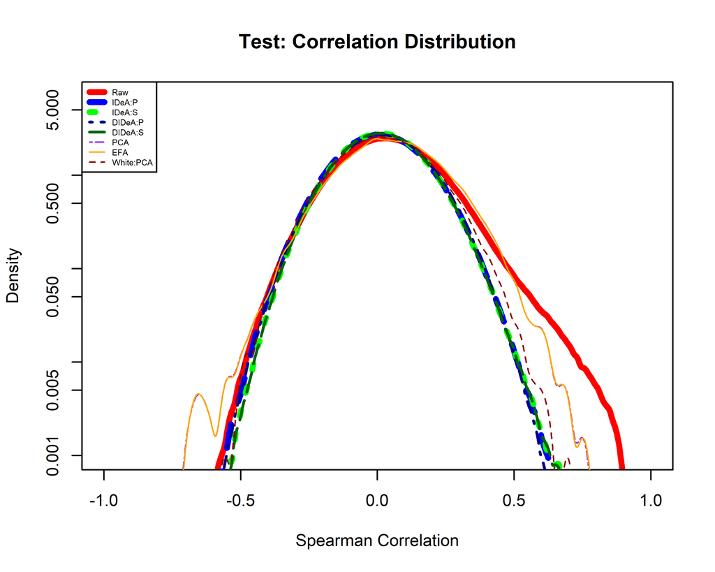

```r
par(cex=0.7)
colors=c("red","blue","green","darkblue","darkgreen","purple","orange","darkred");

plot(rawDen,
     xlim=c(-1,1),
     ylim=c(0.001,7.0),
     col=colors[1],
     lty=1,
     lwd=4,
     log="y",
     main="Test: Correlation Distribution",xlab="Spearman Correlation")

lines(DeDen,col=colors[2],lty=2,lwd=4)
lines(DeSpearDen,col=colors[3],lty=3,lwd=4)
lines(DeDrivDen,col=colors[4],lty=4,lwd=2)
lines(DeDrivSpearDen,col=colors[5],lty=5,lwd=2)

lines(PCADen,col=colors[6],lty=6,lwd=1)
lines(EFADen,col=colors[7],lty=7,lwd=1)
lines(WhiteDen,col=colors[8],lty=8,lwd=1)

names=c("Raw","IDeA:P","IDeA:S","DIDeA:P","DIDeA:S","PCA","EFA","White:PCA")
#colors=c("red","blue","green","blue","green","purple","purple","gray");
lines=c(1,2,3,4,5,6,7,8)
lwds=c(4,4,4,2,2,1,1,1)

legend("topleft",names,col=colors,lty=lines,lwd=lwds,cex=0.50)
```

```r
par(op)
```

### 1.11.1 Differences between train and test ROC AUC

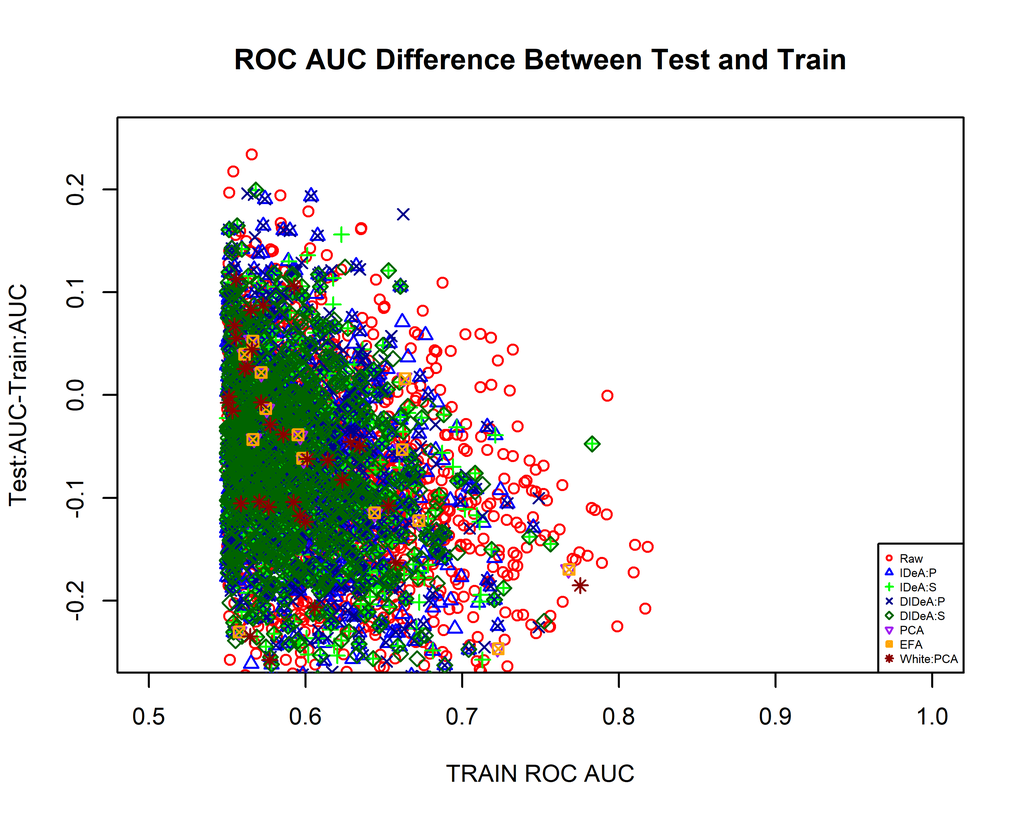

```r
par(op)
par(mfrow=c(1,1),cex=0.7)

AUCResults <- list();
diffAUC <- list();
thenames <- rownames(univar$orderframe)[(rownames(univar$orderframe) %in% colnames(testDataFrame))]
rawAUC <- univar$orderframe[thenames,"ROCAUC"]
thenames <- thenames[rawAUC >= aucTHR]
rawAUC <- univar$orderframe[thenames,"ROCAUC"]
rawAUCTest <- univarTest$orderframe[thenames,"ROCAUC"]
AUCResults$RAW <- rawAUCTest
diffAUC$RAW <-  rawAUCTest-rawAUC
plot(rawAUC,rawAUCTest-rawAUC,
     xlab="TRAIN ROC AUC",
     ylab="Test:AUC-Train:AUC",
     xlim=c(0.5,1.0),
     ylim=c(-0.25,0.25),
     pch=1,
     col=colors[1],
     main="ROC AUC Difference Between Test and Train")

thenames <- rownames(univarDe$orderframe)[!(rownames(univarDe$orderframe) %in% colnames(testDataFrame))]
IDeAP <- univarDe$orderframe[thenames,"ROCAUC"]
thenames <- thenames[IDeAP >= aucTHR]
IDeAP <- univarDe$orderframe[thenames,"ROCAUC"]
IDeAPTest <- univarDeTest$orderframe[thenames,"ROCAUC"]
AUCResults$IDeAP <- IDeAP
AUCResults$IDeAP_T <- IDeAPTest
diffAUC$IDeAP <-  IDeAPTest-IDeAP

points(IDeAP,IDeAPTest-IDeAP,pch=2,col=colors[2])

thenames <- rownames(univarDeSpear$orderframe)[!(rownames(univarDeSpear$orderframe) %in% colnames(testDataFrame))]
IDeAS <- univarDeSpear$orderframe[thenames,"ROCAUC"]
thenames <- thenames[IDeAS >= aucTHR]
IDeAS <- univarDeSpear$orderframe[thenames,"ROCAUC"]
IDeASTest <- univarDeSpearTest$orderframe[thenames,"ROCAUC"]
AUCResults$IDeAS <- IDeAS
AUCResults$IDeAS_T <- IDeASTest
diffAUC$IDeAS <-  IDeASTest-IDeAS

points(IDeAS,IDeASTest-IDeAS,pch=3,col=colors[3])

thenames <- rownames(univarDeDri$orderframe)[!(rownames(univarDeDri$orderframe) %in% colnames(testDataFrame))]
DIDeAP <- univarDeDri$orderframe[thenames,"ROCAUC"]
thenames <- thenames[DIDeAP >= aucTHR]
DIDeAP <- univarDeDri$orderframe[thenames,"ROCAUC"]
DIDeAPTest <- univarDeDriTest$orderframe[thenames,"ROCAUC"]
AUCResults$DIDeAP <- DIDeAP
AUCResults$DIDeAP_T <- DIDeAPTest
diffAUC$DIDeAP <-  DIDeAPTest-DIDeAP

points(DIDeAP,DIDeAPTest-DIDeAP,pch=4,col=colors[4])

thenames <- rownames(univarDeDriSpear$orderframe)[!(rownames(univarDeDriSpear$orderframe) %in% colnames(testDataFrame))]
DIDeAS <- univarDeDriSpear$orderframe[thenames,"ROCAUC"]
thenames <- thenames[DIDeAS >= aucTHR]
DIDeAS <- univarDeDriSpear$orderframe[thenames,"ROCAUC"]
DIDeASTest <- univarDeDriSpearTest$orderframe[thenames,"ROCAUC"]
AUCResults$DIDeAS <- DIDeAS
AUCResults$DIDeAS_T <- DIDeASTest
diffAUC$DIDeAS <-  DIDeASTest-DIDeAS

points(DIDeAS,DIDeASTest-DIDeAS,pch=5,col=colors[5])

thenames <- rownames(univarPCA$orderframe)[!(rownames(univarPCA$orderframe) %in% colnames(testDataFrame))]
PCA <- univarPCA$orderframe[thenames,"ROCAUC"]
thenames <- thenames[PCA >= aucTHR]
PCA <- univarPCA$orderframe[thenames,"ROCAUC"]
PCATest <- univarPCATest$orderframe[thenames,"ROCAUC"]
AUCResults$PCA <- PCA
AUCResults$PCA_T <- PCATest
diffAUC$PCA <-  PCATest-PCA

points(PCA,PCATest-PCA,pch=6,col=colors[6])

thenames <- rownames(univarEFA$orderframe)[!(rownames(univarEFA$orderframe) %in% colnames(testDataFrame))]
EFA <- univarEFA$orderframe[thenames,"ROCAUC"]
thenames <- thenames[EFA >= aucTHR]
EFA <- univarEFA$orderframe[thenames,"ROCAUC"]

EFATest <- univarEFATest$orderframe[thenames,"ROCAUC"]
AUCResults$EFA <- EFA
AUCResults$EFA_T <- EFATest
diffAUC$EFA <-  EFATest-EFA

points(EFA,EFATest-EFA,pch=7,col=colors[7])

thenames <- rownames(univarWhite$orderframe)[!(rownames(univarWhite$orderframe) %in% colnames(testDataFrame))]
WPCA <- univarWhite$orderframe[thenames,"ROCAUC"]
thenames <- thenames[WPCA >= aucTHR]
WPCA <- univarWhite$orderframe[thenames,"ROCAUC"]
WPCATest <- univarWhiteTest$orderframe[thenames,"ROCAUC"]
AUCResults$WPCA <- WPCA
AUCResults$WPCA_T <- WPCATest
diffAUC$WPCA <-  WPCATest-WPCA


points(WPCA,WPCATest-WPCA,pch=8,col=colors[8])


names=c("Raw","IDeA:P","IDeA:S","DIDeA:P","DIDeA:S","PCA","EFA","White:PCA")
pchs=c(1,2,3,4,5,6,7,8)

legend("bottomright",names,col=colors,pch=pchs,cex=0.50)
```

```r
par(op)
```

### 1.11.2 Violin of differences

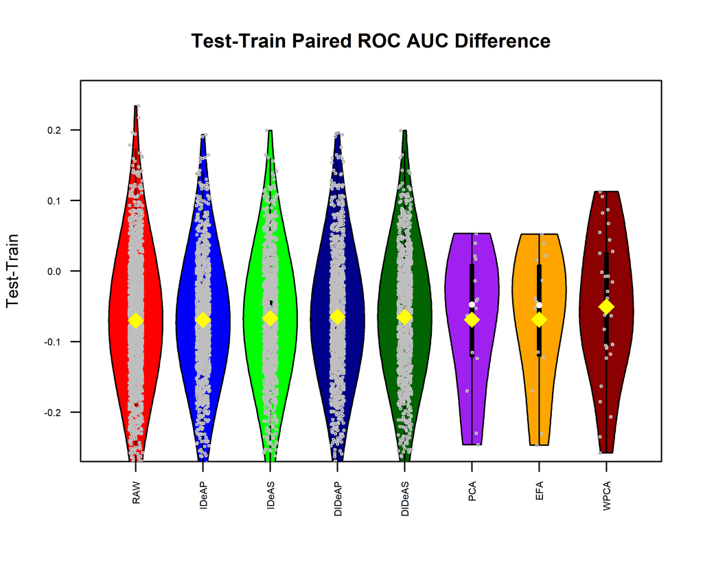

```r
par(op)
par(mfrow=c(1,1),cex=0.7)

vioplot(diffAUC,
        ylim=c(-0.25,0.25),
        ylab="Test-Train",
        main="Test-Train Paired ROC AUC Difference",
        col=colors,
        cex.axis=0.6,
        las=2
)
stripchart(diffAUC, method = "jitter", col = "gray",
           vertical = TRUE, pch = 1, add = TRUE,cex=0.35)
points(1:length(diffAUC),lapply(diffAUC,mean), pch = 18, col = "yellow", cex = 2.25)
```

```r
par(op)
```

### 1.11.3 Distribution of ROC AUC in latent Variables

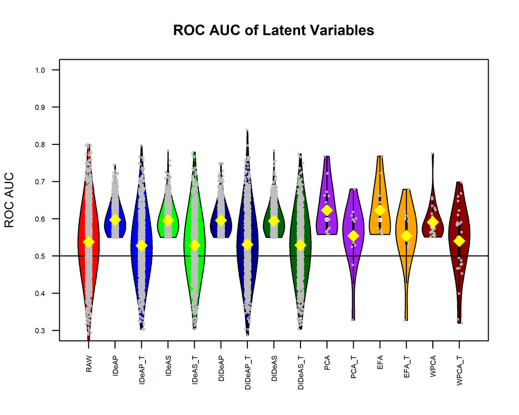

```r
par(op)
par(mfrow=c(1,1),cex=0.7)

colors2 <- length(AUCResults)
colors2[1] <- colors[1];
colors2[2*(1:(length(colors)-1))] <- colors[2:length(colors)]
colors2[1+2*(1:(length(colors)-1))] <- colors[2:length(colors)]
vioplot(AUCResults,
        ylim=c(0.3,1.0),
        ylab="ROC AUC",
        main="ROC AUC of Latent Variables",
        col=colors2,
        cex.axis=0.6,
        las=2
)
abline(h=0.5,col="black")
stripchart(AUCResults, method = "jitter", col = "gray",
           vertical = TRUE, pch = 1, add = TRUE,cex=0.35)
points(1:length(AUCResults),lapply(AUCResults,mean), pch = 18, col = "yellow", cex = 2.25)
```

```r
par(op)
```

### 1.11.4 Differences between train and test Balanced Accuracy

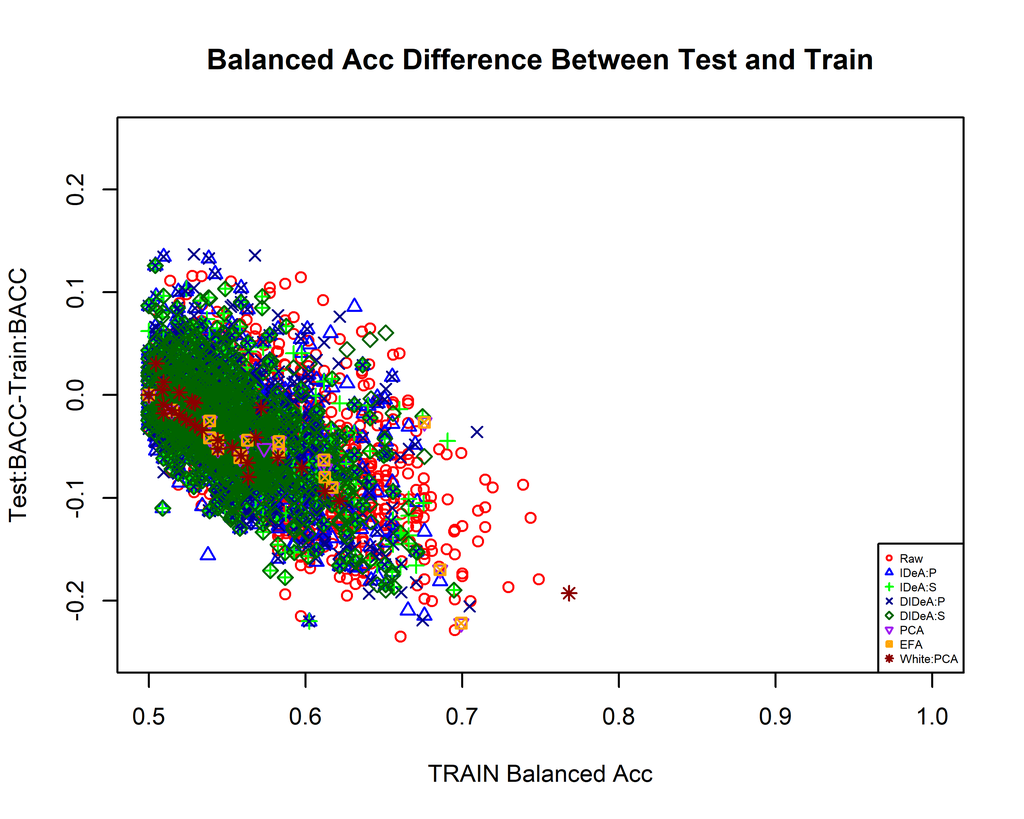

```r
par(op)
par(mfrow=c(1,1),cex=0.7)
BACCTHR <- 0.5
BACCResults <- list();
diffBACC <- list();
thenames <- rownames(univar$orderframe)[(rownames(univar$orderframe) %in% colnames(testDataFrame))]
rawBACC <- univar$orderframe[thenames,"BACC"]
thenames <- thenames[rawBACC >= BACCTHR]
rawBACC <- univar$orderframe[thenames,"BACC"]
rawBACCTest <- univarTest$orderframe[thenames,"BACC"]
BACCResults$RAW <- rawBACCTest
diffBACC$RAW <-  rawBACCTest-rawBACC
plot(rawBACC,rawBACCTest-rawBACC,
     xlab="TRAIN Balanced Acc",
     ylab="Test:BACC-Train:BACC",
     xlim=c(0.5,1.0),
     ylim=c(-0.25,0.25),
     pch=1,
     col=colors[1],
     main="Balanced Acc Difference Between Test and Train")

thenames <- rownames(univarDe$orderframe)[!(rownames(univarDe$orderframe) %in% colnames(testDataFrame))]
IDeAP <- univarDe$orderframe[thenames,"BACC"]
thenames <- thenames[IDeAP >= BACCTHR]
IDeAP <- univarDe$orderframe[thenames,"BACC"]
IDeAPTest <- univarDeTest$orderframe[thenames,"BACC"]
BACCResults$IDeAP <- IDeAP
BACCResults$IDeAP_T <- IDeAPTest
diffBACC$IDeAP <-  IDeAPTest-IDeAP

points(IDeAP,IDeAPTest-IDeAP,pch=2,col=colors[2])

thenames <- rownames(univarDeSpear$orderframe)[!(rownames(univarDeSpear$orderframe) %in% colnames(testDataFrame))]
IDeAS <- univarDeSpear$orderframe[thenames,"BACC"]
thenames <- thenames[IDeAS >= BACCTHR]
IDeAS <- univarDeSpear$orderframe[thenames,"BACC"]
IDeASTest <- univarDeSpearTest$orderframe[thenames,"BACC"]
BACCResults$IDeAS <- IDeAS
BACCResults$IDeAS_T <- IDeASTest
diffBACC$IDeAS <-  IDeASTest-IDeAS

points(IDeAS,IDeASTest-IDeAS,pch=3,col=colors[3])

thenames <- rownames(univarDeDri$orderframe)[!(rownames(univarDeDri$orderframe) %in% colnames(testDataFrame))]
DIDeAP <- univarDeDri$orderframe[thenames,"BACC"]
thenames <- thenames[DIDeAP >= BACCTHR]
DIDeAP <- univarDeDri$orderframe[thenames,"BACC"]
DIDeAPTest <- univarDeDriTest$orderframe[thenames,"BACC"]
BACCResults$DIDeAP <- DIDeAP
BACCResults$DIDeAP_T <- DIDeAPTest
diffBACC$DIDeAP <-  DIDeAPTest-DIDeAP

points(DIDeAP,DIDeAPTest-DIDeAP,pch=4,col=colors[4])

thenames <- rownames(univarDeDriSpear$orderframe)[!(rownames(univarDeDriSpear$orderframe) %in% colnames(testDataFrame))]
DIDeAS <- univarDeDriSpear$orderframe[thenames,"BACC"]
thenames <- thenames[DIDeAS >= BACCTHR]
DIDeAS <- univarDeDriSpear$orderframe[thenames,"BACC"]
DIDeASTest <- univarDeDriSpearTest$orderframe[thenames,"BACC"]
BACCResults$DIDeAS <- DIDeAS
BACCResults$DIDeAS_T <- DIDeASTest
diffBACC$DIDeAS <-  DIDeASTest-DIDeAS

points(DIDeAS,DIDeASTest-DIDeAS,pch=5,col=colors[5])

thenames <- rownames(univarPCA$orderframe)[!(rownames(univarPCA$orderframe) %in% colnames(testDataFrame))]
PCA <- univarPCA$orderframe[thenames,"BACC"]
thenames <- thenames[PCA >= BACCTHR]
PCA <- univarPCA$orderframe[thenames,"BACC"]
PCATest <- univarPCATest$orderframe[thenames,"BACC"]
BACCResults$PCA <- PCA
BACCResults$PCA_T <- PCATest
diffBACC$PCA <-  PCATest-PCA

points(PCA,PCATest-PCA,pch=6,col=colors[6])

thenames <- rownames(univarEFA$orderframe)[!(rownames(univarEFA$orderframe) %in% colnames(testDataFrame))]
EFA <- univarEFA$orderframe[thenames,"BACC"]
thenames <- thenames[EFA >= BACCTHR]
EFA <- univarEFA$orderframe[thenames,"BACC"]

EFATest <- univarEFATest$orderframe[thenames,"BACC"]
BACCResults$EFA <- EFA
BACCResults$EFA_T <- EFATest
diffBACC$EFA <-  EFATest-EFA

points(EFA,EFATest-EFA,pch=7,col=colors[7])

thenames <- rownames(univarWhite$orderframe)[!(rownames(univarWhite$orderframe) %in% colnames(testDataFrame))]
WPCA <- univarWhite$orderframe[thenames,"BACC"]
thenames <- thenames[WPCA >= BACCTHR]
WPCA <- univarWhite$orderframe[thenames,"BACC"]
WPCATest <- univarWhiteTest$orderframe[thenames,"BACC"]
BACCResults$WPCA <- WPCA
BACCResults$WPCA_T <- WPCATest
diffBACC$WPCA <-  WPCATest-WPCA


points(WPCA,WPCATest-WPCA,pch=8,col=colors[8])


names=c("Raw","IDeA:P","IDeA:S","DIDeA:P","DIDeA:S","PCA","EFA","White:PCA")
pchs=c(1,2,3,4,5,6,7,8)

legend("bottomright",names,col=colors,pch=pchs,cex=0.50)
```

```r
par(op)
```

### 1.11.5 Violin of differences

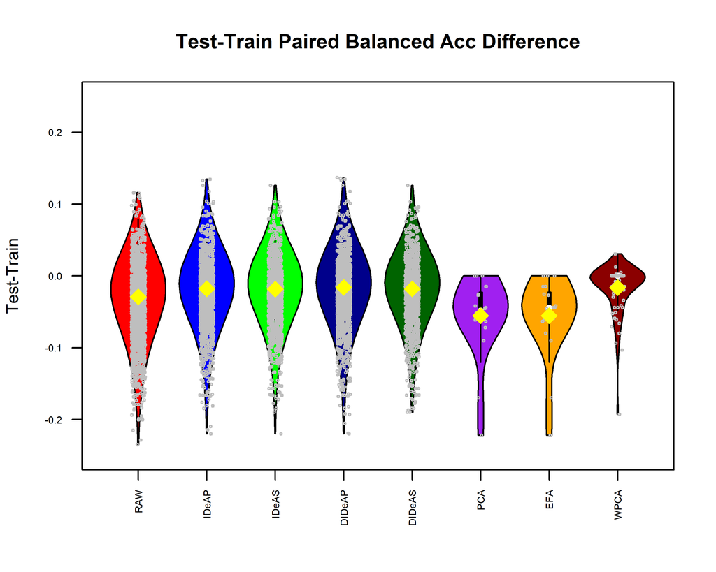

```r
par(op)
par(mfrow=c(1,1),cex=0.7)

vioplot(diffBACC,
        ylim=c(-0.25,0.25),
        ylab="Test-Train",
        main="Test-Train Paired Balanced Acc Difference",
        col=colors,
        cex.axis=0.6,
        las=2
)
stripchart(diffBACC, method = "jitter", col = "gray",
           vertical = TRUE, pch = 1, add = TRUE,cex=0.35)
points(1:length(diffBACC),lapply(diffBACC,mean), pch = 18, col = "yellow", cex = 2.25)
```

```r
par(op)
```

### 1.11.6 Distribution of Balanced Acc in latent Variables

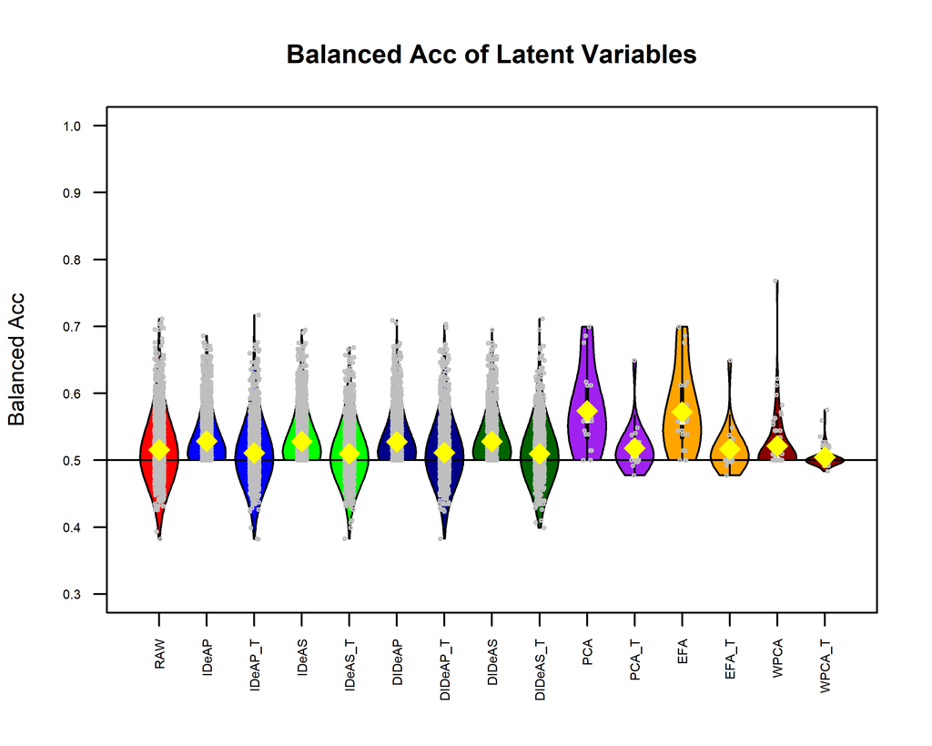

```r
par(op)
par(mfrow=c(1,1),cex=0.7)

colors2 <- length(BACCResults)
colors2[1] <- colors[1];
colors2[2*(1:(length(colors)-1))] <- colors[2:length(colors)]
colors2[1+2*(1:(length(colors)-1))] <- colors[2:length(colors)]
vioplot(BACCResults,
        ylim=c(0.3,1.0),
        ylab="Balanced Acc",
        main="Balanced Acc of Latent Variables",
        col=colors2,
        cex.axis=0.6,
        las=2
)
abline(h=0.5,col="black")
stripchart(BACCResults, method = "jitter", col = "gray",
           vertical = TRUE, pch = 1, add = TRUE,cex=0.35)
points(1:length(BACCResults),lapply(BACCResults,mean), pch = 18, col = "yellow", cex = 2.25)
```

```r
par(op)
```

### 1.11.7 Differences between train and test IDI

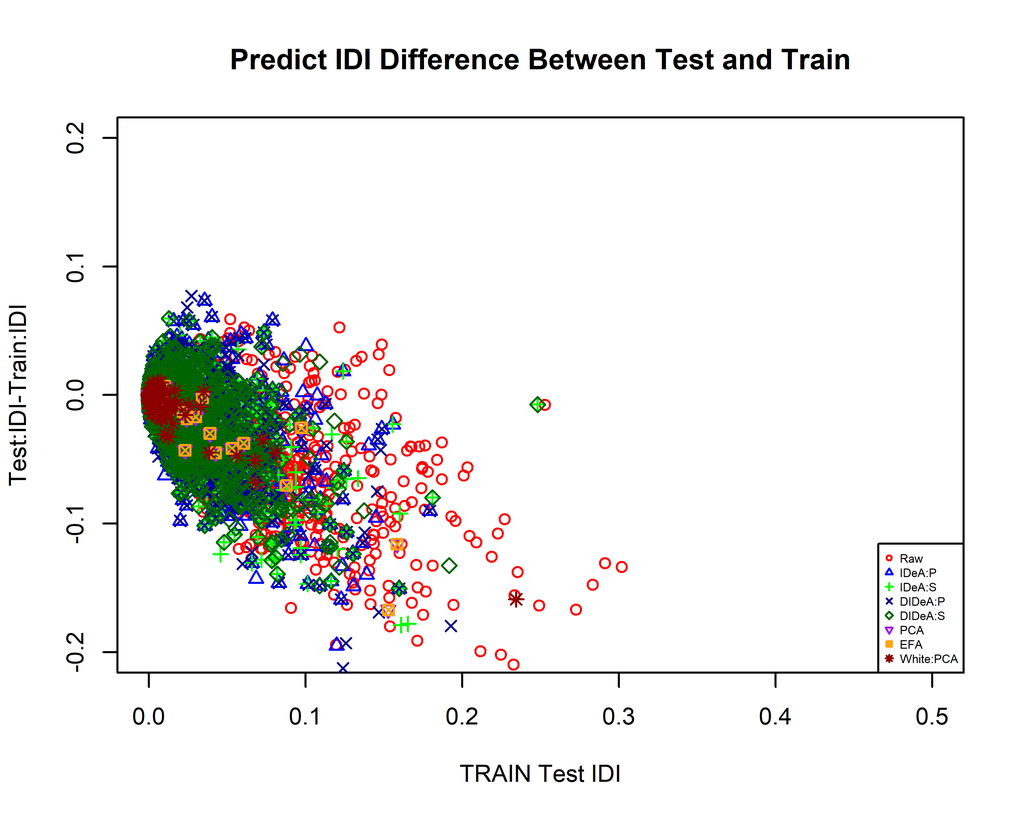

```r
par(op)
par(mfrow=c(1,1),cex=0.7)

testIDI <- list();
diffIDI <- list();
rawIDI <- univar$orderframe$IDI
rawIDITest <- univarTest$orderframe$IDI
testIDI$RAW <- rawIDITest
diffIDI$RAW <-  rawIDITest-rawIDI
plot(rawIDI,rawIDITest-rawIDI,
     xlab="TRAIN Test IDI",
     ylab="Test:IDI-Train:IDI",
     xlim=c(0,0.5),
     ylim=c(-0.2,0.2),
     pch=1,
     col=colors[1],
     main="Predict IDI Difference Between Test and Train")

IDeAP <- univarDe$orderframe$IDI[!(rownames(univarDe$orderframe) %in% colnames(testDataFrame))]
IDeAPTest <-univarDeTest$orderframe$IDI[!(rownames(univarDe$orderframe) %in% colnames(testDataFrame))]
testIDI$IDeAP <- IDeAP
testIDI$IDeAP_T <- IDeAPTest
diffIDI$IDeAP <-  IDeAPTest-IDeAP

points(IDeAP,IDeAPTest-IDeAP,pch=2,col=colors[2])

IDeAS <- univarDeSpear$orderframe$IDI[!(rownames(univarDeSpearTest$orderframe) %in% colnames(testDataFrame))]
IDeASTest <- univarDeSpearTest$orderframe$IDI[!(rownames(univarDeSpearTest$orderframe) %in% colnames(testDataFrame))]
testIDI$IDeAS <- IDeAS
testIDI$IDeAS_T <- IDeASTest
diffIDI$IDeAS <-  IDeASTest-IDeAS

points(IDeAS,IDeASTest-IDeAS,pch=3,col=colors[3])

DIDeAP <- univarDeDri$orderframe$IDI[!(rownames(univarDeDriTest$orderframe) %in% colnames(testDataFrame))]
DIDeAPTest <- univarDeDriTest$orderframe$IDI[!(rownames(univarDeDriTest$orderframe) %in% colnames(testDataFrame))]
testIDI$DIDeAP <- DIDeAP
testIDI$DIDeAP_T <- DIDeAPTest
diffIDI$DIDeAP <-  DIDeAPTest-DIDeAP

points(DIDeAP,DIDeAPTest-DIDeAP,pch=4,col=colors[4])

DIDeAS <- univarDeDriSpear$orderframe$IDI[!(rownames(univarDeDriSpearTest$orderframe) %in% colnames(testDataFrame))]
DIDeASTest <- univarDeDriSpearTest$orderframe$IDI[!(rownames(univarDeDriSpearTest$orderframe) %in% colnames(testDataFrame))]
testIDI$DIDeAS <- DIDeAS
testIDI$DIDeAS_T <- DIDeASTest
diffIDI$DIDeAS <-  DIDeASTest-DIDeAS

points(DIDeAS,DIDeASTest-DIDeAS,pch=5,col=colors[5])

PCA <- univarPCA$orderframe$IDI[!(rownames(univarPCA$orderframe) %in% colnames(testDataFrame))]
PCATest <- univarPCATest$orderframe$IDI[!(rownames(univarPCA$orderframe) %in% colnames(testDataFrame))]
testIDI$PCA <- PCA
testIDI$PCA_T <- PCATest
diffIDI$PCA <-  PCATest-PCA

points(PCA,PCATest-PCA,pch=6,col=colors[6])

EFA <- univarEFA$orderframe$IDI[!(rownames(univarEFA$orderframe) %in% colnames(testDataFrame))]
EFATest <- univarEFATest$orderframe$IDI[!(rownames(univarEFA$orderframe) %in% colnames(testDataFrame))]
testIDI$EFA <- EFA
testIDI$EFA_T <- EFATest
diffIDI$EFA <-  EFATest-EFA

points(EFA,EFATest-EFA,pch=7,col=colors[7])

WPCA <- univarWhite$orderframe$IDI[!(rownames(univarWhite$orderframe) %in% colnames(testDataFrame))]
WPCATest <- univarWhiteTest$orderframe$IDI[!(rownames(univarWhite$orderframe) %in% colnames(testDataFrame))]
testIDI$WPCA <- WPCA
testIDI$WPCA_T <- WPCATest
diffIDI$WPCA <-  WPCATest-WPCA


points(WPCA,WPCATest-WPCA,pch=8,col=colors[8])


names=c("Raw","IDeA:P","IDeA:S","DIDeA:P","DIDeA:S","PCA","EFA","White:PCA")
pchs=c(1,2,3,4,5,6,7,8)

legend("bottomright",names,col=colors,pch=pchs,cex=0.50)
```

```r
par(op)
```

### 1.11.8 Violin of differences

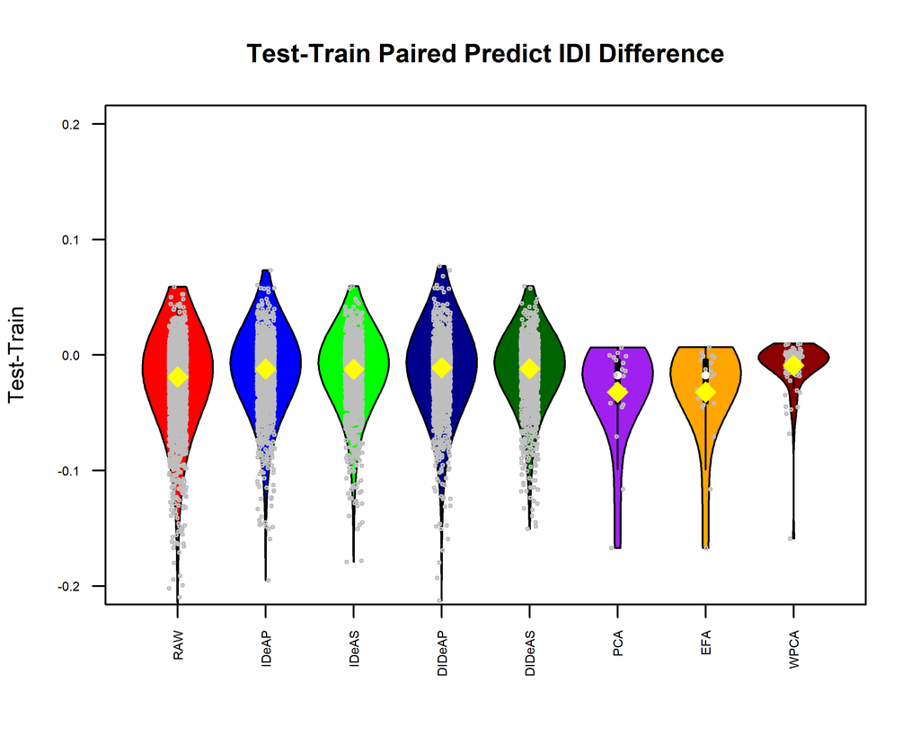

```r
par(op)
par(mfrow=c(1,1),cex=0.7)

vioplot(diffIDI,
        ylim=c(-0.2,0.2),
        ylab="Test-Train",
        main="Test-Train Paired Predict IDI Difference",
        col=colors,
        cex.axis=0.6,
        las=2
)
stripchart(diffIDI, method = "jitter", col = "gray",
           vertical = TRUE, pch = 1, add = TRUE,cex=0.35)
points(1:length(diffIDI),lapply(diffIDI,mean), pch = 18, col = "yellow", cex = 2.25)
```

```r
par(op)
```

### 1.11.9 Distribution of Predict IDI in latent Variables

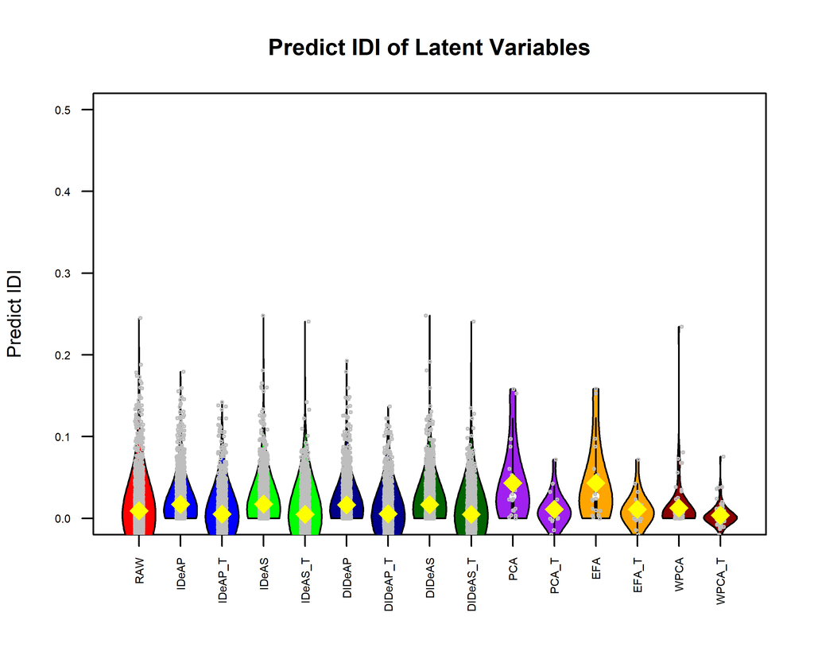

```r
par(op)
par(mfrow=c(1,1),cex=0.7)

colors2 <- length(testIDI)
colors2[1] <- colors[1];
colors2[2*(1:(length(colors)-1))] <- colors[2:length(colors)]
colors2[1+2*(1:(length(colors)-1))] <- colors[2:length(colors)]
vioplot(testIDI,
        ylim=c(0.0,0.5),
        ylab="Predict IDI",
        main="Predict IDI of Latent Variables",
        col=colors2,
        cex.axis=0.6,
        las=2
)
stripchart(testIDI, method = "jitter", col = "gray",
           vertical = TRUE, pch = 1, add = TRUE,cex=0.35)
points(1:length(testIDI),lapply(testIDI,mean), pch = 18, col = "yellow", cex = 2.25)
```

```r
par(op)
```

### 1.11.10 The tables

```r
pander::pander(univarTest$orderframe[1:TopVariables,univariate_columns])
```

|  | caseMean | caseStd | controlMean | controlStd | controlKSP | IDI | ROCAUC | cStatCorr |
| --- | --- | --- | --- | --- | --- | --- | --- | --- |
| **g1CNS105** | 0.283 | 0.282 | 0.0162 | 0.1600 | 0.0332 | 0.1358 | 0.671 | 0.818 |
| **g5G04** | 0.330 | 0.237 | 0.1007 | 0.1624 | 0.2515 | 0.1058 | 0.609 | 0.817 |
| **g1CNS91** | 0.338 | 0.300 | 0.0772 | 0.1321 | 0.0522 | 0.1680 | 0.665 | 0.810 |
| **g1int845** | 0.190 | 0.184 | 0.0135 | 0.0976 | 0.3854 | 0.1604 | 0.637 | 0.809 |
| **g1int844** | 0.333 | 0.263 | 0.1043 | 0.1655 | 0.0359 | 0.0778 | 0.574 | 0.799 |

```r
pander::pander(univarDeTest$orderframe[1:TopVariables,univariate_columns])
```

|  | caseMean | caseStd | controlMean | controlStd | controlKSP | IDI | ROCAUC | cStatCorr |
| --- | --- | --- | --- | --- | --- | --- | --- | --- |
| **La_g1int1525** | -0.0552 | 0.0710 | 0.0101 | 0.0734 | 0.475 | 0.0892 | 0.617 | 0.745 |
| **g1int817** | -0.1974 | 0.1548 | -0.0673 | 0.1256 | 0.443 | 0.0977 | 0.627 | 0.745 |
| **g8F04** | 0.0243 | 0.0866 | -0.0540 | 0.0796 | 0.831 | 0.1502 | 0.679 | 0.743 |
| **g1int1362** | -0.2281 | 0.2214 | -0.0681 | 0.1133 | 0.225 | 0.0312 | 0.558 | 0.733 |
| **g1CNS74** | 0.1023 | 0.1304 | 0.0224 | 0.1169 | 0.140 | 0.1253 | 0.735 | 0.730 |

```r
pander::pander(univarDeSpearTest$orderframe[1:TopVariables,univariate_columns])
```

|  | caseMean | caseStd | controlMean | controlStd | controlKSP | IDI | ROCAUC | cStatCorr |
| --- | --- | --- | --- | --- | --- | --- | --- | --- |
| **La_g1CNS36** | 0.0617 | 0.1844 | -0.0413 | 0.0650 | 0.6345 | 0.2407 | 0.736 | 0.783 |
| **g5F04** | 0.2693 | 0.2779 | 0.0757 | 0.1141 | 0.0174 | 0.0951 | 0.632 | 0.762 |
| **La_g1int1702** | 0.0422 | 0.0713 | -0.0220 | 0.0648 | 0.2836 | 0.1013 | 0.612 | 0.756 |
| **g1int1656** | 0.1104 | 0.1852 | -0.0214 | 0.0794 | 0.9746 | 0.0226 | 0.542 | 0.756 |
| **g1int817** | -0.1974 | 0.1548 | -0.0673 | 0.1256 | 0.4428 | 0.0977 | 0.627 | 0.745 |

```r
pander::pander(univarDeDriTest$orderframe[1:TopVariables,univariate_columns])
```

|  | caseMean | caseStd | controlMean | controlStd | controlKSP | IDI | ROCAUC | cStatCorr |
| --- | --- | --- | --- | --- | --- | --- | --- | --- |
| **g1int1363** | -0.2208 | 0.2001 | -0.06395 | 0.0978 | 0.0766 | 0.0232 | 0.563 | 0.764 |
| **g1int843** | 0.1520 | 0.1903 | 0.03628 | 0.1043 | 0.0412 | 0.0291 | 0.531 | 0.756 |
| **g3F01** | -0.0404 | 0.1329 | 0.03670 | 0.0820 | 0.3820 | 0.0349 | 0.609 | 0.750 |
| **La_g1int429** | 0.0225 | 0.1068 | -0.04890 | 0.0832 | 0.1976 | 0.0708 | 0.649 | 0.749 |
| **La_g1int1335** | 0.0660 | 0.0858 | -0.00225 | 0.0616 | 0.5675 | 0.0131 | 0.523 | 0.749 |

```r
pander::pander(univarDeDriSpearTest$orderframe[1:TopVariables,univariate_columns])
```

|  | caseMean | caseStd | controlMean | controlStd | controlKSP | IDI | ROCAUC | cStatCorr |
| --- | --- | --- | --- | --- | --- | --- | --- | --- |
| **g1CNS105** | 0.2830 | 0.2817 | 0.0162 | 0.1600 | 0.0332 | 0.1358 | 0.671 | 0.818 |
| **La_g1CNS36** | 0.0617 | 0.1844 | -0.0413 | 0.0650 | 0.6345 | 0.2407 | 0.736 | 0.783 |
| **g1int1363** | -0.2208 | 0.2001 | -0.0640 | 0.0978 | 0.0766 | 0.0232 | 0.563 | 0.764 |
| **La_g1int1702** | 0.0422 | 0.0713 | -0.0220 | 0.0648 | 0.2836 | 0.1013 | 0.612 | 0.756 |
| **g1int1681** | 0.1324 | 0.1750 | 0.0102 | 0.0952 | 0.7107 | 0.0124 | 0.530 | 0.755 |

```r
pander::pander(univarPCATest$orderframe[1:TopVariables,univariate_columns])
```

|  | caseMean | caseStd | controlMean | controlStd | controlKSP | IDI | ROCAUC | cStatCorr |
| --- | --- | --- | --- | --- | --- | --- | --- | --- |
| **RC3** | 74.3672 | 226.9522 | -50.5697 | 92.3193 | 0.00337 | 0.0423 | 0.598 | 0.768 |
| **g8F04** | 0.0243 | 0.0866 | -0.0540 | 0.0796 | 0.83114 | 0.1502 | 0.679 | 0.743 |
| **RC15** | 35.1859 | 84.7521 | -23.9264 | 62.0576 | 0.73857 | -0.0142 | 0.476 | 0.722 |
| **g1int895** | 0.1192 | 0.1081 | 0.0416 | 0.0876 | 0.37224 | 0.0834 | 0.602 | 0.720 |
| **g1int1071** | 0.1004 | 0.1088 | 0.0262 | 0.1472 | 0.74573 | 0.0197 | 0.553 | 0.675 |

```r
pander::pander(univarEFATest$orderframe[1:TopVariables,univariate_columns])
```

|  | caseMean | caseStd | controlMean | controlStd | controlKSP | IDI | ROCAUC | cStatCorr |
| --- | --- | --- | --- | --- | --- | --- | --- | --- |
| **MR3** | 74.3206 | 226.7484 | -50.5380 | 92.2465 | 0.00344 | 0.0424 | 0.599 | 0.768 |
| **g8F04** | 0.0243 | 0.0866 | -0.0540 | 0.0796 | 0.83114 | 0.1502 | 0.679 | 0.743 |
| **MR15** | 35.1126 | 84.5235 | -23.8766 | 61.8582 | 0.74515 | -0.0142 | 0.476 | 0.723 |
| **g1int895** | 0.1192 | 0.1081 | 0.0416 | 0.0876 | 0.37224 | 0.0834 | 0.602 | 0.720 |
| **g1int1071** | 0.1004 | 0.1088 | 0.0262 | 0.1472 | 0.74573 | 0.0197 | 0.553 | 0.675 |

```r
pander::pander(univarWhiteTest$orderframe[1:TopVariables,univariate_columns])
```

|  | caseMean | caseStd | controlMean | controlStd | controlKSP | IDI | ROCAUC | cStatCorr |
| --- | --- | --- | --- | --- | --- | --- | --- | --- |
| **L2** | 0.3683 | 1.2305 | -0.5177 | 0.5916 | 0.938 | 0.0755 | 0.590 | 0.775 |
| **g8F04** | 0.0243 | 0.0866 | -0.0540 | 0.0796 | 0.831 | 0.1502 | 0.679 | 0.743 |
| **g1int895** | 0.1192 | 0.1081 | 0.0416 | 0.0876 | 0.372 | 0.0834 | 0.602 | 0.720 |
| **g1int1071** | 0.1004 | 0.1088 | 0.0262 | 0.1472 | 0.746 | 0.0197 | 0.553 | 0.675 |
| **g6F10** | 0.0877 | 0.1126 | 0.0300 | 0.0907 | 0.673 | 0.0287 | 0.589 | 0.673 |

```r
topUni <- univar$orderframe$Name[1:TopVariables]
topDe <- univarDe$orderframe$Name[1:TopVariables]
topDeSpear <- univarDeSpear$orderframe$Name[1:TopVariables]
topDeDri <- univarDeDri$orderframe$Name[1:TopVariables]
topDeDriSpear <- univarDeDriSpear$orderframe$Name[1:TopVariables]
topPCA <- univarPCA$orderframe$Name[1:TopVariables]
topEFA <- univarEFA$orderframe$Name[1:TopVariables]
topPCAWhite <- univarWhite$orderframe$Name[1:TopVariables]
```

### 1.11.11 Model of top variables

```r
par(mfrow=c(1,2),cex=0.6)

lmRAW <- glm(paste(outcome,"~."),
             trainDataFrame[,c(outcome,topUni)],
             family="binomial")
prRaw <- predictionStats_binary(cbind(testDataFrame[,outcome],predict(lmRAW,testDataFrame)),"Top Raw",cex=0.75)
```

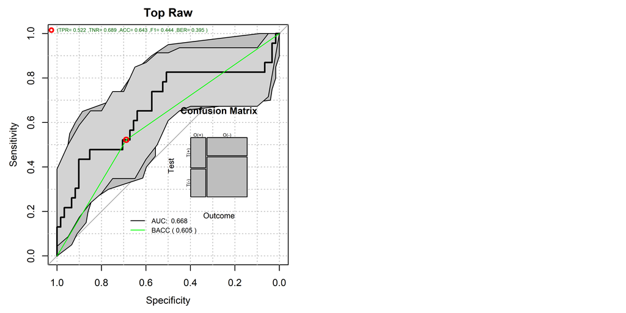

```r
lmDe <- glm(paste(outcome,"~."),
            DEdataframe[,c(outcome,topDe)],
            family="binomial")
prDe <- predictionStats_binary(cbind(predTestDe[,outcome],predict(lmDe,predTestDe)),"Top IDeA:P",cex=0.75)
```

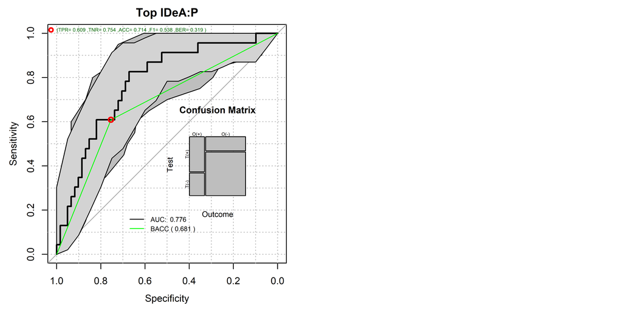

```r
lmDeSpear <- glm(paste(outcome,"~."),
            DEdataframeSpear[,c(outcome,topDeSpear)],
            family="binomial")
prSpear <- predictionStats_binary(cbind(predTestDeSpear[,outcome],predict(lmDeSpear,predTestDeSpear)),"Top IDeA:S",cex=0.75)
```

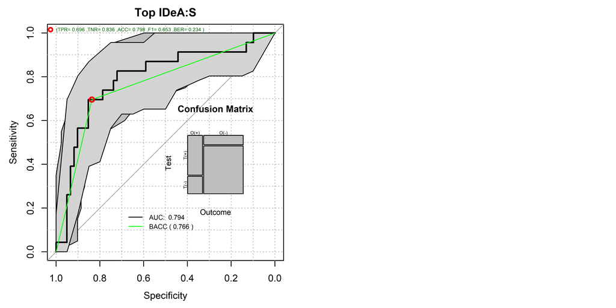

```r
lmDri <- glm(paste(outcome,"~."),
            DriDEdataframe[,c(outcome,topDeDri)],
            family="binomial")
prDri <- predictionStats_binary(cbind(predTestDe[,outcome],predict(lmDri,predTestDri)),"Top DIDeA:P",cex=0.75)
```

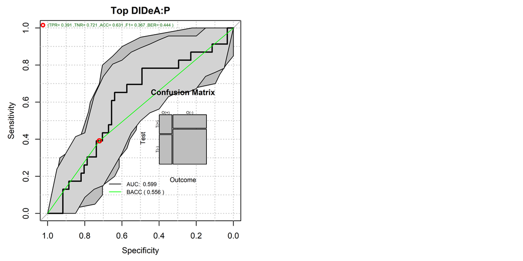

```r
lmDriSpear <- glm(paste(outcome,"~."),
            DriDEdataframeSpear[,c(outcome,topDeDriSpear)],
            family="binomial")
prDriSpear <- predictionStats_binary(cbind(predTestDriSpear[,outcome],predict(lmDriSpear,predTestDriSpear)),"Top DIDeA:S",cex=0.7)
```

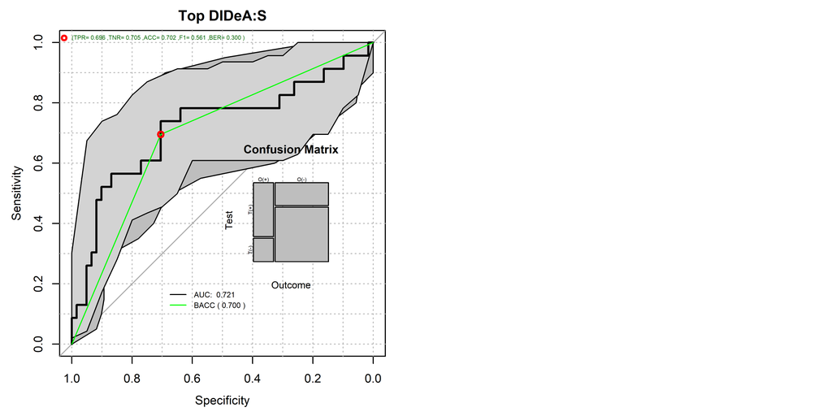

```r
lmPCA <- glm(paste(outcome,"~."),
            PCA_Train[,c(outcome,topPCA)],
            family="binomial")
prPCA <- predictionStats_binary(cbind(PCA_Predicted[,outcome],predict(lmPCA,PCA_Predicted)),"Top PCA",cex=0.75)
```

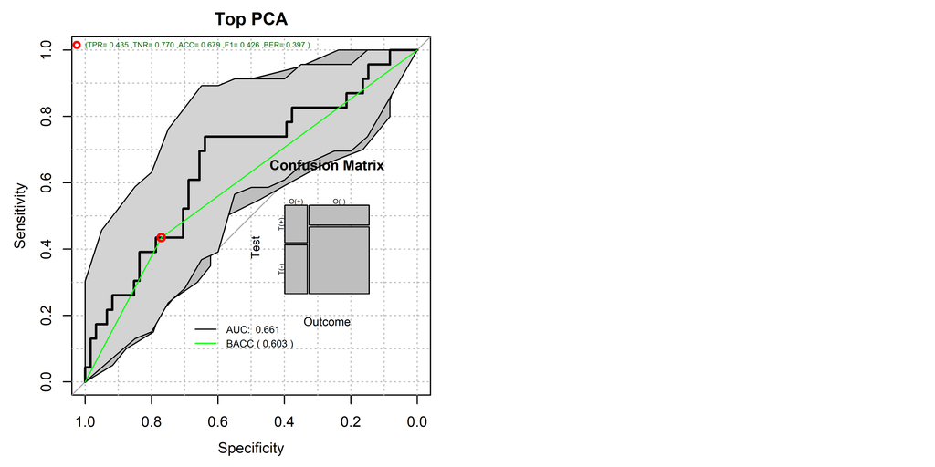

```r
lmEFA <- glm(paste(outcome,"~."),
            EFA_Train[,c(outcome,topEFA)],
            family="binomial")
prEFA <- predictionStats_binary(cbind(EFA_Predicted[,outcome],predict(lmEFA,EFA_Predicted)),"Top EFA",cex=0.75)
```

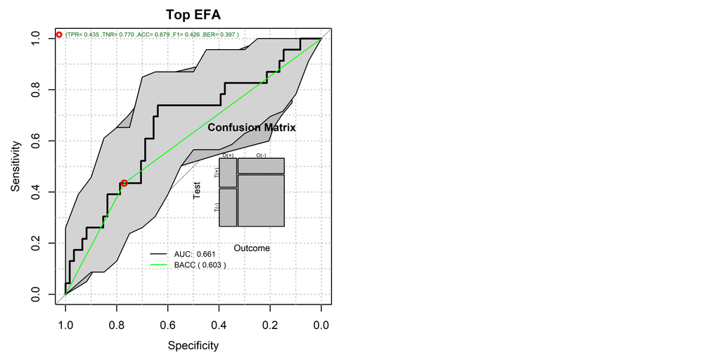

```r
lmPCAW <- glm(paste(outcome,"~."),
            PCAWhite_Train[,c(outcome,topPCAWhite)],
            family="binomial")
prWPCA <- predictionStats_binary(cbind(PCAWhitePredicted[,outcome],predict(lmPCAW,PCAWhitePredicted)),"Top White:PCA",cex=0.75)
```

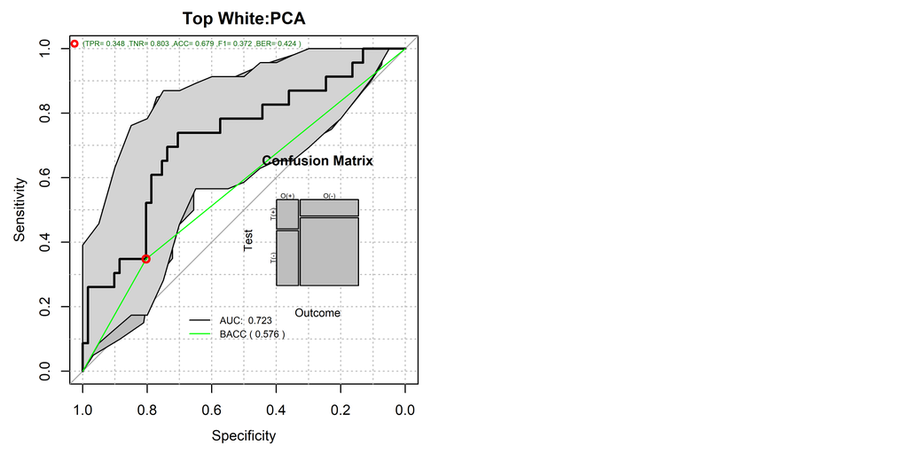

```r
par(op)
```

### 1.11.12 The Performance Tables and Plots

```r
par(cex=0.6)

 aucs <- prRaw$aucs
  aucs <- rbind(aucs,prDe$aucs)
  aucs <- rbind(aucs,prSpear$aucs)
  aucs <- rbind(aucs,prDri$aucs)
  aucs <- rbind(aucs,prDriSpear$aucs)
  aucs <- rbind(aucs,prPCA$aucs)
  aucs <- rbind(aucs,prEFA$aucs)
  aucs <- rbind(aucs,prWPCA$aucs)


  rownames(aucs) <- c("RAW",
                        "IDeA:P",
                        "IDeA:S",
                        "DIDeA:P",
                        "DIDeA:S",
                        "PCA",
                        "EFA",
                        "WPCA"
                        )

  pander::pander(aucs)
```

|  | est | lower | upper |
| --- | --- | --- | --- |
| **RAW** | 0.668 | 0.520 | 0.816 |
| **IDeA:P** | 0.776 | 0.666 | 0.886 |
| **IDeA:S** | 0.794 | 0.677 | 0.911 |
| **DIDeA:P** | 0.599 | 0.461 | 0.736 |
| **DIDeA:S** | 0.721 | 0.581 | 0.861 |
| **PCA** | 0.661 | 0.525 | 0.798 |
| **EFA** | 0.661 | 0.525 | 0.798 |
| **WPCA** | 0.723 | 0.595 | 0.850 |

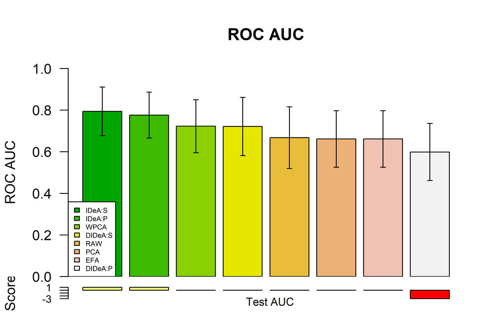

```r
  bpAUC <- barPlotCiError(as.matrix(aucs),
                          metricname = "ROC AUC",
                          thesets = "Test AUC",
                          themethod = rownames(aucs),
                          main = "ROC AUC",
                          offsets = c(0.5,1),
                          scoreDirection = ">",
                          ho=0.5,
                          args.legend = list(bg = "white",x="bottomleft",inset=c(0.0,0),cex=0.5),
                          col = terrain.colors(nrow(aucs))
                          )
```

```r
 berror <- prRaw$berror
  berror <- rbind(berror,prDe$berror)
  berror <- rbind(berror,prSpear$berror)
  berror <- rbind(berror,prDri$berror)
  berror <- rbind(berror,prDriSpear$berror)
  berror <- rbind(berror,prPCA$berror)
  berror <- rbind(berror,prEFA$berror)
  berror <- rbind(berror,prWPCA$berror)


  rownames(berror) <- rownames(aucs)
  pander::pander(berror)
```

|  | 50% | 2.5% | 97.5% |
| --- | --- | --- | --- |
| **RAW** | 0.392 | 0.273 | 0.510 |
| **IDeA:P** | 0.322 | 0.209 | 0.431 |
| **IDeA:S** | 0.229 | 0.127 | 0.347 |
| **DIDeA:P** | 0.442 | 0.326 | 0.562 |
| **DIDeA:S** | 0.302 | 0.192 | 0.421 |
| **PCA** | 0.399 | 0.277 | 0.514 |
| **EFA** | 0.395 | 0.280 | 0.516 |
| **WPCA** | 0.428 | 0.313 | 0.527 |

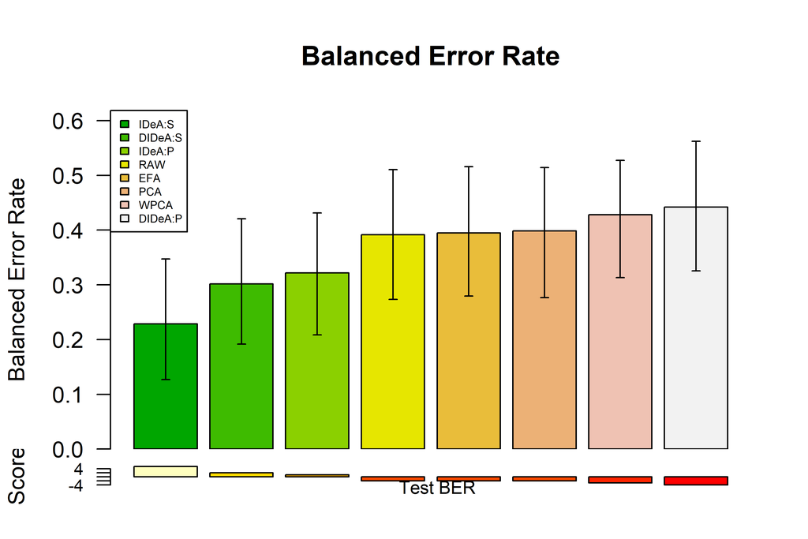

```r
  bpBER <- barPlotCiError(as.matrix(berror),
                          metricname = "Balanced Error Rate",
                          thesets = "Test BER",
                          themethod = rownames(aucs),
                          main = "Balanced Error Rate",
                          offsets = c(0.5,1),
                          scoreDirection = "<",
                          ho=0.5,
                          args.legend = list(bg = "white",x="topleft",inset=c(0.0,0),cex=0.5),
                          col = terrain.colors(nrow(aucs))
                          )
```

```r
  par(op)
```